# Statistik mit R für die Module W501, W873 und W662 (Teil I)

Bodo Sturm, HTWK Leipzig

01.10.2026

> *IMAGINE a world without statistics. Governments would fumble in the dark, investors would waste money and electorates would struggle to hold their political leaders to account.*

> — The Economist (Feb 25th 2012)

## Über diese Veranstaltung

#### Allgemeines

In dieser Veranstaltung werden **Konzepte der deskriptiven und induktiven Statistik** mit R vorgestellt. **Ziel** ist es, statistische Probleme mit Hilfe von R zu lösen und entsprechende Ergebnisse interpretieren zu können. R (https://www.r-project.org/) ist eine frei verfügbare Statistik-Software.

Das Teilmodul (W501/W873) bzw. Modul (W662) setzt Grundkenntnisse in Statistik voraus. Diese müssen selbst erarbeitet bzw. wieder aufgefrischt werden. Die Veranstaltung basiert auf dem Lehrbuch: Sturm, B. (2019): “Statistik. Eine Einführung mit R”, GUC-Verlag, 2. Auflage (https://fww.htwk-leipzig.de/sturm/lehrbuecher-prof-dr-bodo-sturm/).

Der OPAL-Kurs enthält:

- Skript (dieses pdf/html).
- Aufgabenblätter zum selbstständigen Lösen (pro Kapitel ein Blatt).
- ZIP-Datei “dataR.zip”. Diese Datei bitte **LOKAL abspeichern und extrahieren** (d.h., in einem Ordner auf Ihrem Rechner abspeichern und entpacken). Oder Sie gehen direkt auf GitHub mit `https://github.com/bodosturm/dataR.git`, dann auf Code und auf Download ZIP. Anschließend lokal extrahieren.
- Sessionplan: In diesem txt file sind stichpunktartig die wichtigsten Inhalte aufgelistet.
- R Exkurse: Ein Ordner mit txt files, die verschiedene statistische Probleme mit R lösen.
- Lösungshinweise zu den Übungsaufgaben (werden nach dem Besprechen in der Veranstaltung in OPAL eingestellt).
- Lernvideos zur Anwendung von R.

Es ist Ihre Aufgabe, sich mit den Rechnern im Zuse-Bau (wenn Sie diese nutzen: Zugang, Baumstruktur usw.) und natürlich auch mit Ihrem Rechner (Baumstruktur) vertraut zu machen. Für Studierende mit Laptop: Nutzen Sie die WLAN-Verbindung mit eduroam. Der Download von R und erste Schritte sind im o.g. Lehrbuch “Statistik. Eine Einführung mit R” beschrieben.

Sie können gerne **KI als Coach** nutzen, z.B. zur Fehlersuche im Code oder zur Erklärung der Anwendung eines Befehls. Versuchen Sie dabei möglichst mit den einfachen Befehlen aus der Vorlesung zu arbeiten (lassen Sie die KI mit base R arbeiten und möglichst nicht mit extra Paketen). Denken Sie aber immer daran, dass Sie am Ende in der Lage sein sollten, die Übungsaufgaben eigenständig bearbeiten zu können.

**Warum R** und nicht gleich KI? Der zentrale Vorteil von Statistik-Software wie R ist Transparenz und Reproduzierbarkeit: Jeder Rechenschritt ist im Code sichtbar, nachvollziehbar und exakt wiederholbar – wenn sich z.B. die Rohdaten ändern, läuft das gleiche Skript erneut und liefert garantiert konsistente, überprüfbare Ergebnisse, während eine KI-Antwort eine Blackbox bleibt und bei Auswertungen und Erläuterungen auch mal halluzinieren kann. Der Trade-off: R erfordert mehr Vorwissen und Zeitaufwand, wogegen KI wie Claude schneller zu einer Antwort kommt, aber ohne die gleiche Transparenz. Faustregel “KI für schnelle Exploration, R-Code für alles, was überprüfbar, wiederholbar und zitierfähig sein muss”.

Struktur der Veranstaltung:

1. Es gibt eine Vorlesung am Rechner mit Anwendung von Statistik in R. Das Skript wird gestellt (vgl. OPAL-Kurs). Die Mitschriften der Vorlesungen werden in OPAL veröffentlicht (txt file mit Datum).
2. Es gibt Aufgabenblätter (pdf, vgl. OPAL-Kurs), die die Studierenden selbstständig (!) bearbeiten. In der Veranstaltung werden nur Probleme bei der Lösung besprochen. **Fragen zu den Aufgaben bitte vorab per email.** Wenn Sie keine Fragen haben, heißt das für mich, dass alles OK ist.
3. Die **Klausureinsicht** für meine Veranstaltungen findet immer zu Beginn des nachfolgenden Semesters (im April bzw. Oktober) in meiner Sprechzeit statt (Termine werden über Webpage/OPAL bekanntgegeben).

#### Hinweise für W501 (BWM) und W873 (GMM)

Der Umfang des Teilmoduls beträgt 90 Min. pro Woche (2 SWS, 50% des Moduls Quantitative Methoden). Bitte tragen Sie sich in den OPAL-Kurs (“W501 Quantitative Methoden” oder “W873 Quantitative Methoden der Wirtschaftswissenschaften”) ein. Dieses pdf/html ist das Skript zum Modul. Es gibt gemäß PrüfO eine Klausur (90 min.) für das Modul. Die Klausur wird “klassisch” durchgeführt, d.h. mit Stift und Papier. **Hilfsmittel**: Taschenrechner (gem. Positiv-Liste der FWW) und ein A4-Blatt (mit Vorder- und Rückseite, frei beschriftet oder bedruckt). Die **Klausur für dieses Teilmodul** umfasst Verständnis und Anwendung von statistischen Methoden, Interpretation von Ergebnissen sowie die Anwendung von R-Code.

#### Hinweise für W662 (BWB/IMB)

Der Umfang des Moduls beträgt 2 x 90 Min. pro Woche (4 SWS). Bitte tragen Sie sich in den OPAL-Kurs für “W662 Angewandte Statistik” ein. Das Skript zum Modul hat zwe Teile (Teil I: dieses pdf/html, Teil II: Multiple Regression als pdf). Es gibt gemäß PrüfO eine Klausur (120 min.) für das Modul. Die Klausur wird “klassisch” durchgeführt, d.h. mit Stift und Papier. **Hilfsmittel**: Taschenrechner (gem. Positiv-Liste der FWW) und ein A4-Blatt (mit Vorder- und Rückseite, frei beschriftet oder bedruckt). Die **Klausur** umfasst Verständnis und Anwendung von statistischen Methoden, Interpretation von Ergebnissen sowie die Anwendung von R-Code.

## Basics in R (alle Module)

### Ein- und Ausgabe in R

Nach dem Öffnen von R erwartet die **Console** hinter dem `>` Zeichen die Eingabe eines Befehls (Ausführung mit ENTER). Zum Beispiel kann in die Console die Rechenoperation `2+2` eingegeben werden. Ergebnis:

[1] 4

In der Console stehen Eingabe und Ausgabe zusammen. Dies ist ein Nachteil, wenn Ein- und Ausgabe umfangreicher werden. Daher werden wir im Folgenden den in R implementierten **Editor** zur Eingabe nutzen (es gibt eine Reihe von komfortableren Editoren wie z.B. R Studio, https://www.rstudio.com/). Der Editor kann als .txt oder .R file abgespeichert (und später wieder geöffnet und ausgeführt) werden. Die Ausgabe erfolgt dann in der Console.

Es gibt zwei Optionen für die Befehlsübergabe vom Editor an die Console:

1. Markieren des Befehls im Editor und Tastenkombination “Strg+R” oder
2. Markieren des Befehls im Editor und Ausführen von “Ausführung Zeile oder Auswahl” in der R Menü-Zeile.

Alles hinter der Raute (`#`) ist in R ein **Kommentar**. Zum besseren Verständnis der Befehle werden diese oft kommentiert. Am Ende des Tages ist es das Ziel, ein kommentiertes R Skript zu haben, welches einen Datensatz einliest und diesen leicht reproduzierbar auswertet.

### R als Rechner

R kann als Rechner verwendet werden. Dabei gilt “Punkt- vor Strichrechnung”. Die Eingabe erfolgt einfach in der Console (Ausführung mit ENTER) oder im Editor (vgl. unten).

```r
1+2        # Addition
```

```
## [1] 3
```

```r
2*5        # Multiplikation
```

```
## [1] 10
```

```r
3/5        # Division
```

```
## [1] 0.6
```

```r
2+4*5      # Punkt- vor Strichrechnung
```

```
## [1] 22
```

Weitere Rechenoperationen:

```r
sqrt(9)    # Wurzel
```

```
## [1] 3
```

```r
3^2        # Quadrat
```

```
## [1] 9
```

```r
log(100)   # Natürlicher Logarithmus
```

```
## [1] 4.6052
```

R ist **objektbasiert**. Objekte sind z.B. Vektoren oder Matrizen. Es gibt Regeln für die Objektbezeichnung: R ist **case sensitiv**, d.h., `x` ist nicht `X`. Objektnamen dürfen nicht mit Zahlen beginnen: also zum Beispiel `x1` aber nicht `1x`. Die Bezeichnung von Objekten erfolgt mit dem **Zuweisungsoperator** `<-`.

```r
x <- 9     # Dem Objekt x wird mit "<-" die Zahl 9 zugewiesen
x          # Ausgabe von x
```

```
## [1] 9
```

Die `[1]` in der Ausgabe zeigt an, dass dahinter das 1. Element der Ausgabe steht (hier die `9`).

```r
class(x)   # Welche Art von Objekt ist x?
```

```
## [1] "numeric"
```

### Zahlenreihen

Der Befehl `seq()` erzeugt eine Zahlenreihe, wobei Beginn, Ende und Abstand (getrennt durch ein Komma) anzugeben sind. Wir definieren hier eine Zahlenreihe von 0 bis 20 mit Abstand 2. Wir weisen der Zahlenreihe mit dem Zuweisungsoperator `<-` eine Bezeichnung `a` zu.

```r
a <- seq(0, 20, 2) # Definition des Objektes a
a                  # Ausgabe von a
```

```
##  [1]  0  2  4  6  8 10 12 14 16 18 20
```

Die Reihe ganzer Zahlen von z.B. 8 bis 14 kann mit `seq(8, 14, 1)`, aber auch mit `8:14` definiert werden.

```r
8:14               # ganze Zahlen von 8 bis 14
```

```
## [1]  8  9 10 11 12 13 14
```

```r
a[1:4]             # gebe die Elemente 1 bis 4 von a aus
```

```
## [1] 0 2 4 6
```

### Abbildungen mit `plot()`

Der Befehl für Abbildungen ist `plot()`, wobei ein Vektor als x-Variable und ein Vektor als y-Variable anzugeben ist. Hier nutzen wir die eben definierte Zahlenreihe $a$ und $a^{2}-40$.

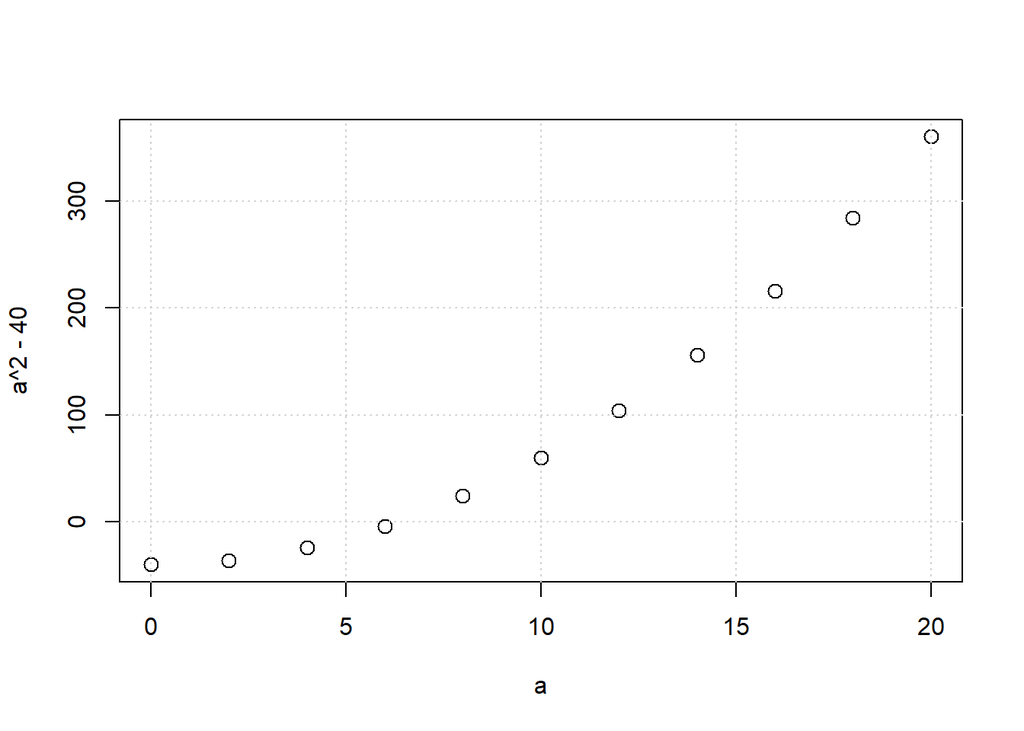

```r
plot(a, a^2-40, cex = 1.3)  # Trennung der Argumente durch Komma
grid()                      # Gitternetz (wenn man will)
```

Mit `cex = 1.3` werden die Punkte in der Abbildung 30% größer dargestellt als normal (`cex = 1`). Der Befehl `grid()` legt ein Gitternetz über die Abbildung. Noch ein Beispiel für eine solche Abbildung:

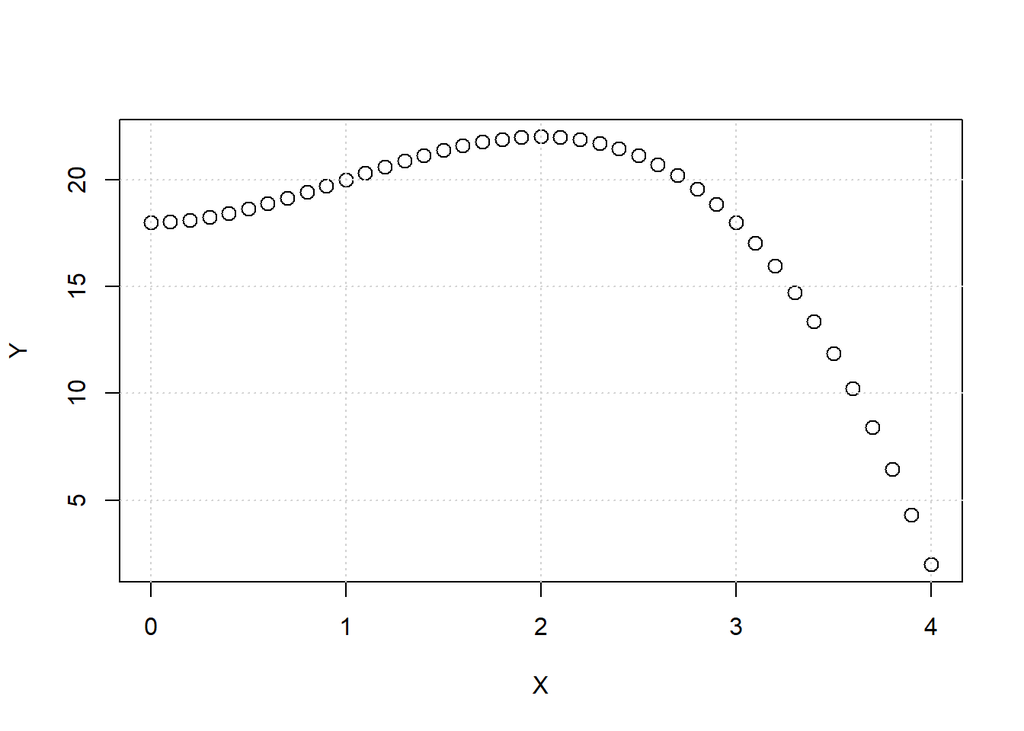

```r
X <- seq(0, 4, 0.1)       # Trennung der Argumente durch Komma
Y <- 3*X^2 + 18 - X^3
plot(X, Y, cex = 1.3)
grid()
```

### Einige sinnvolle Befehle

Der Befehl `max()` liefert das Maximum einer Zahlenreihe, `min()` das Minimum und `length()` liefert die Länge des Vektors. Der Befehl `sum()` liefert die Summe der Elemente eines Vektors.

```r
E <- 1:100  # 1:100 ist der gleiche Output wie seq(1, 100, 1)
sum(E)      # Summe von E
```

```
## [1] 5050
```

```r
100*101/2   # Gauss-Formel sum(E) = n*(n+1)/2
```

```
## [1] 5050
```

```r
min(E); max(E) # Das Semikolon spart den Zeilenumbruch.
```

```
## [1] 1
```

```
## [1] 100
```

```r
length(E)   # Länge des Vektors
```

```
## [1] 100
```

Betrachten wir das arithmetische Mittel von `E`. Hierfür haben wir zwei Optionen:

```r
n <- length(E); n # Definiere Variable n
```

```
## [1] 100
```

```r
(1/n)*sum(E)      # Berechne das arithmetische Mittel
```

```
## [1] 50.5
```

oder

```r
mean(E)           # Funktion für das arithmetische Mittel
```

```
## [1] 50.5
```

R kann mit Vektoren rechnen.

```r
a <- 1:5; a       # Das Semikolon spart den Zeilenumbruch
```

```
## [1] 1 2 3 4 5
```

```r
a*4               # Elemente des Vektors * 4
```

```
## [1]  4  8 12 16 20
```

```r
a/10              # Elemente des Vektors : 10
```

```
## [1] 0.1 0.2 0.3 0.4 0.5
```

```r
a + 3             # Elemente des Vektors + 3
```

```
## [1] 4 5 6 7 8
```

Nun wollen wir zeigen, wie der **Zugriff** auf einzelne Elemente eines Vektors (und später auch einer Matrix) funktioniert. Wir definieren uns eine Zahlenreihe `b` mit `c()` und greifen auf bestimmte Werte von `b` zu.

```r
b <- c(6:10, 99, 5:13); b
```

```
##  [1]  6  7  8  9 10 99  5  6  7  8  9 10 11 12 13
```

```r
mean(b)     # arithmetisches Mittel von b
```

```
## [1] 14.667
```

```r
b[6]        # Ausgabe des 6. Elements von b mit []-Klammer
```

```
## [1] 99
```

```r
b[6] <- NA  # weise dem Ausreißer 99 den Wert NA (= not available) zu
b           # Ausgabe der neuen Reihe b mit b[6] = NA
```

```
##  [1]  6  7  8  9 10 NA  5  6  7  8  9 10 11 12 13
```

```r
mean(b, na.rm = TRUE) # Mittel von b, wobei die NA nicht berücksichtigt werden
```

```
## [1] 8.6429
```

Wie bekommt man raus, ob eine Zahlenreihe NAs (not available) hat?

```r
summary(b)  # guter Überblick über einen Vektor
```

```
##    Min. 1st Qu.  Median    Mean 3rd Qu.    Max.     NAs
##    5.00    7.00    8.50    8.64   10.00   13.00       1
```

```r
is.na(b)    # geht auch so, Antwort ist TRUE or FALSE
```

```
##  [1] FALSE FALSE FALSE FALSE FALSE  TRUE FALSE FALSE FALSE FALSE FALSE FALSE
## [13] FALSE FALSE FALSE
```

Der Befehl `summary()` ist extrem nützlich, insbesondere bei der Analyse von quantitativen Daten.

**Einlesen von Daten in R**: Wir werden hier nur mit Dateien des Typs “csv” (comma separated values) arbeiten. Solche csv-Dateien lassen sich leicht aus Excel generieren (und dann als csv abspeichern).

Option 1: Einlesen einer csv-Datei direkt von **GitHub** (Internet-Verbindung nötig) mit

`https://raw.githubusercontent.com/bodosturm/dataR/main/dateiname.csv`

in Anführungszeichen und mit `read.csv()`.

```r
# Ein Beispiel:
data <- read.csv("https://raw.githubusercontent.com/bodosturm/dataR/main/patients.csv")
data                                     # Ausgabe des Objektes data
```

| fem | age | weight |
| --- | --- | --- |
| 0 | 20 | 58 |
| 1 | 66 | 63 |
| 0 | 80 | 62 |
| 1 | 44 | 59 |
| 1 | 50 | 85 |
| 0 | 55 | 90 |
| 1 | 16 | 78 |

Option 2: Einlesen der csv-Datei aus einem Ordner auf Ihrem Rechner (Annahme: Alle Dateien aus dataR.zip liegen extrahiert in diesem Ordner). Hierbei sind die folgenden Schritte zu absolvieren:

1. Wo ist das aktuelle **Arbeitsverzeichnis**? Der Befehl `getwd()` gibt das aktuelle Arbeitsverzeichnis aus.

```r
getwd()     # Wo ist das Arbeitsverzeichnis (working directory = wd)?
```

```
## [1] "C:/Users/sturm/01_HTWK 20_Dez_2022/01_Vorlesungen/08 WS 2x2 SWS QMStatistikmitR GMM W873 BWM W501/01_WS 2026,27"
```

2. Ändern des Arbeitsverzeichnisses über: Aktiviere Console => Datei => Verzeichnis Ändern … Dann den Ordner aussuchen, der das Arbeitsverzeichnis sein soll, und OK klicken ODER mit `setwd()` das Arbeitsverzeichnis definieren. Wenn `setwd()` genutzt wird, muss der gesamte **Pfad** bis zum Arbeitsverzeichnis angegeben werden (in Anführungszeichen und mit `/` und nicht mit `\`).
3. Einlesebefehl: `Objektname <- read.csv("Datei.csv")`

```r
# Das Beispiel oben (hier auskommentiert):
# setwd("C:/Users/sturm/Desktop/dataR")    # setze das Arbeitsverzeichnis
# data <- read.csv("patients.csv")         # Einlesen der Datei, Objektdefinition
# data                                     # Ausgabe des Objektes data
```

Der Befehl `read.csv()` ist nur ein Einlesebefehl. R gibt das Objekt nur aus, wenn man den Objektnamen (hier `data`) auch ausführt.

```r
summary(data)                           # Ein erster Überblick über data
```

```
##       fem             age           weight
##  Min.   :0.000   Min.   :16.0   Min.   :58.0
##  1st Qu.:0.000   1st Qu.:32.0   1st Qu.:60.5
##  Median :1.000   Median :50.0   Median :63.0
##  Mean   :0.571   Mean   :47.3   Mean   :70.7
##  3rd Qu.:1.000   3rd Qu.:60.5   3rd Qu.:81.5
##  Max.   :1.000   Max.   :80.0   Max.   :90.0
```

Die Bezeichnung des eingelesenen Objektes in R (hier `data`) ist beliebig. ABER: Objekte sollten NIE so genannt werden, wie Variablen in der einzulesenden Datei heißen. Nachdem ein Objekt in R definiert wurde, muss man auf die Variablen in diesem Objekt zugreifen.

Wir wollen nun auf einzelne Variablen im Objekt `data` zugreifen.

Methode 1: Zugriff mit `$`-Symbol:

```r
names(data)    # Variablennamen im Objekt data
```

```
## [1] "fem"    "age"    "weight"
```

```r
data$age       # Zugriff auf age mit $
```

```
## [1] 20 66 80 44 50 55 16
```

```r
mean(data$age) # z.B. Mittelwert von age
```

```
## [1] 47.286
```

Methode 2: Verwendung des Befehls `attach()`:

```r
attach(data)  # erklärt data zum "aktuellen" Objekt
weight        # Ausgabe der Variablen weight
```

```
## [1] 58 63 62 59 85 90 78
```

```r
mean(age)     # Mittelwert von age
```

```
## [1] 47.286
```

```r
detach(data)  # macht attach() rückgängig
```

In diesem Dokument nutzen wir sowohl `attach()` als auch das `$` Zeichen, um auf Variablen zuzugreifen.

Ein paar nützliche Befehle für **Datentabellen** in R:

```r
attach(data); length(age)
```

```
## [1] 7
```

```r
data[4,2]      # 4. Zeile und 2. Spalte
```

```
## [1] 44
```

```r
data[1:3,]     # die ersten 3 Zeilen der gesamten Datentabelle
```

|  | fem | age | weight |
| --- | --- | --- | --- |
| 1 | 0 | 20 | 58 |
| 2 | 1 | 66 | 63 |
| 3 | 0 | 80 | 62 |

```r
data[3,]       # 3. Zeile
```

|  | fem | age | weight |
| --- | --- | --- | --- |
| 3 | 0 | 80 | 62 |

```r
data[,c(2,3)]  # Spalte 2 und 3
```

| age | weight |
| --- | --- |
| 20 | 58 |
| 66 | 63 |
| 80 | 62 |
| 44 | 59 |
| 50 | 85 |
| 55 | 90 |
| 16 | 78 |

```r
dim(data)      # Zahl Zeilen (7) und Zahl Spalten (3) von data
```

```
## [1] 7 3
```

```r
detach(data)
```

Manchmal ist es sinnvoll, die Ausgabe zu runden. Das geht leicht mit `round()`.

```r
x <- 1:4           # Definition x
x/3
```

```
## [1] 0.33333 0.66667 1.00000 1.33333
```

```r
round(x/3, 2)      # Runde den Vektor x/3 auf zwei Kommastellen
```

```
## [1] 0.33 0.67 1.00 1.33
```

Wenn man Werte für $X$ pro Zeitpunkt $t$ hat, ist der Befehl `diff()` hilfreich. Der Befehl `diff()` berechnet $X_t - X_{t-1}$. Damit lässt sich dann leicht die Wachstumsrate in Prozent bestimmen mit $g_t = 100*(X_t - X_{t-1})/X_{t-1}$.

```r
t <- 1:4; X <- c(10, 12, 14, 16) # Definition Werte für t und X
tab <- data.frame(t, X); tab     # Erzeuge eine Datentabelle
```

| t | X |
| --- | --- |
| 1 | 10 |
| 2 | 12 |
| 3 | 14 |
| 4 | 16 |

```r
delta <- diff(X); delta          # Differenzenbildung, hier nur 3 Werte
```

```
## [1] 2 2 2
```

```r
g <- 100*diff(X)/X[1:3]; g       # Wachstumsrate g in Prozent
```

```
## [1] 20.000 16.667 14.286
```

```r
g <- c(NA, g); g                 # NA für t=1
```

```
## [1]     NA 20.000 16.667 14.286
```

```r
tab <- cbind(tab, g); tab        # Schreibe g in die Datentabelle tab
```

| t | X | g |
| --- | --- | --- |
| 1 | 10 | NA |
| 2 | 12 | 20.000 |
| 3 | 14 | 16.667 |
| 4 | 16 | 14.286 |

Manchmal will man die Zeilen einer Tabelle **sortieren** nach einer Variable.

```r
age <- c(19, 22, 24, 46, 53)                # Alter in Jahre
Tn <- c("Pia", "Klaus", "Dieter", "Horst", "Uschi") # Namen der Tn
income <- c(25, 31, 17, 33, 67)             # Einkommen in 1000 Euro
tab <- data.frame(Tn, age, income); tab     # Erzeuge eine Datentabelle
```

| Tn | age | income |
| --- | --- | --- |
| Pia | 19 | 25 |
| Klaus | 22 | 31 |
| Dieter | 24 | 17 |
| Horst | 46 | 33 |
| Uschi | 53 | 67 |

```r
# die 3 ältesten Tn
sorted_tab <- tab[order(tab$age, decreasing = TRUE), ]
top_3_age <- head(sorted_tab, 3); top_3_age
```

|  | Tn | age | income |
| --- | --- | --- | --- |
| 5 | Uschi | 53 | 67 |
| 4 | Horst | 46 | 33 |
| 3 | Dieter | 24 | 17 |

```r
# die 3 ärmsten (in Einkommen) Tn
sorted_tab <- tab[order(tab$income, decreasing = FALSE), ]
top_3_inc <- head(sorted_tab, 3); top_3_inc
```

|  | Tn | age | income |
| --- | --- | --- | --- |
| 3 | Dieter | 24 | 17 |
| 1 | Pia | 19 | 25 |
| 2 | Klaus | 22 | 31 |

Last but not least: Die **Hilfe in R** wird mit `?Befehl` aufgerufen. Dies setzt voraus, dass man den Befehl kennt. Beispiele sind `?hist()` und `?mean()`.

### Bedingte Auswertungen

Häufig will man eine bedingte Auswertung durchführen, z.B. für einen Datensatz mit Männern und Frauen das mittlere Alter aller Frauen und aller Männer getrennt voneinander bestimmen. R bietet hierfür mehrere Methoden an.

Methode über eine Bedingung in `[]`-Klammer:

```r
data$age[data$fem == 1]         # alle Beobachtungen für Alter, wenn fem = 1
```

```
## [1] 66 44 50 16
```

```r
mean(data$age[data$fem == 1])   # mittleres Alter aller Frauen
```

```
## [1] 44
```

```r
mean(data$age[data$fem == 0])   # mittleres Alter aller Männer
```

```
## [1] 51.667
```

Methode über `subset()`:

```r
data_fem <- subset(data, data$fem == 1, )  # nur Frauen aus data und alle Spalten
data_fem
```

|  | fem | age | weight |
| --- | --- | --- | --- |
| 2 | 1 | 66 | 63 |
| 4 | 1 | 44 | 59 |
| 5 | 1 | 50 | 85 |
| 7 | 1 | 16 | 78 |

```r
mean(data_fem$age)
```

```
## [1] 44
```

```r
data_m <- subset(data, fem == 0, )         # nur Männer aus data und alle Spalten
data_m
```

|  | fem | age | weight |
| --- | --- | --- | --- |
| 1 | 0 | 20 | 58 |
| 3 | 0 | 80 | 62 |
| 6 | 0 | 55 | 90 |

```r
mean(data_m$age)
```

```
## [1] 51.667
```

Man kann auch Bedingungen mit UND (`&`) oder ODER (`|`) verknüpfen. Zum Beispiel: Wir wollen alle Frauen, die älter sind als 50 Jahre, ausgeben lassen (vgl. Exkurs: Logische Bedingungen):

```r
data_fem50 <- subset(data, data$fem == 1 & data$age > 50, ); data_fem50
```

|  | fem | age | weight |
| --- | --- | --- | --- |
| 2 | 1 | 66 | 63 |

```r
data[data$fem == 1 & data$age > 50, ]           # auch das geht mit []-Klammer
```

|  | fem | age | weight |
| --- | --- | --- | --- |
| 2 | 1 | 66 | 63 |

Generell kann man sich merken, dass runde Klammern `()` in R für Funktionen genutzt werden, z.B. bei `subset()` oder `summary()`. Eckige Klammern `[]` werden für bedingte Auswertungen oder Matrixangaben genutzt, z.B. bei `data[1:3,]`.

## Qualitative Daten (alle Module)

### Häufigkeitstabelle

Für ein qualitatives Merkmal wird zunächst die absolute Häufigkeit $n_i$ der $i=1, ..., m$ Merkmalsausprägungen bestimmt und mit einer Häufigkeitstabelle ausgegeben. In der Häufigkeitstabelle wird dann für jede Merkmalsausprägung $i$ der Wert $n_i$ angegeben. Es gilt $\sum_{i=1}^{m}n_i=n$.

Betrachten wir das folgende Beispiel:

```r
setwd("C:/Users/sturm/Desktop/dataR")    # Definiere das Arbeitsverz.
data <- read.csv("profession.csv")       # Einlesen der Datei
# data <- read.csv("https://raw.githubusercontent.com/bodosturm/dataR/main/profession.csv")
data[1:3,]                               # Ausgabe Zeile 1 bis 3, alle Spalten
```

|  | Gender | Sector | Degree |
| --- | --- | --- | --- |
| 1 | female | education | university |
| 2 | female | marketing | vocational education |
| 3 | male | education | university |

```r
attach(data)                             # Erkläre data zum aktuellen Objekt
```

Das Objekt `data` hat drei Merkmale bzw. Variablen (`Gender`, `Sector`, `Degree`), die alle qualitativ sind (nominal skaliert). Der Befehl `table()` liefert die absolute Häufigkeitstabelle für eine Variable.

```r
table(Gender)   # Häufigkeitstabelle für Gender
```

```
## Gender
## female   male
##     14     16
```

```r
sum(table(Gender))
```

```
## [1] 30
```

14 von 30 Befragten sind Frauen. Die Häufigkeitstabellen für `Sector` und `Degree` ergeben sich entsprechend.

```r
table(Sector); table(Degree)
```

```
## Sector
## automobile  education  marketing  transport
##          6         11          6          7
```

```
## Degree
##                 none           university vocational education
##                    6                   13                   11
```

Mit `table()` kann auch leicht ermittelt werden, wie viele Beobachtungen einer Reihe eine bestimmte Bedingung erfüllen. Betrachten wir die Zahlenreihe {3, 9, 1, 5, 6, 7, 10, 4, 2}. Wir wollen wissen, ob ein Element der Zahlenreihe kleiner oder gleich 4 ist. Das Ergebnis dieser Abfrage ist entweder `TRUE` oder `FALSE` und diese Ausprägungen können wieder leicht mit `table()` ausgewertet werden.

```r
x <- c(3, 9, 1, 5, 6, 7, 10, 4, 2)
x <= 4
```

```
## [1]  TRUE FALSE  TRUE FALSE FALSE FALSE FALSE  TRUE  TRUE
```

```r
table(x <= 4)
```

```
##
## FALSE  TRUE
##     5     4
```

Eine absolute Häufigkeitsverteilung kann mit `prop.table()` in eine relative Häufigkeitsverteilung überführt werden. Die relative Häufigkeitsverteilung stellt die relativen Häufigkeiten $h_i=n_i/n$ für jede Merkmalsausprägung $i=1, ..., m$ dar. Es gilt $\sum_{i=1}^{m}h_i=1$. Hier im Beispiel:

```r
prop.table(table(Gender))        # greift auf table() zu
```

```
## Gender
##  female    male
## 0.46667 0.53333
```

47% der Befragten sind Frauen, 53% sind Männer.

```r
sum(prop.table(table(Gender)))   # Summe der rel. Häufigkeiten muss 1 sein
```

```
## [1] 1
```

### Barplot

Häufigkeitstabellen werden graphisch mit Hilfe eines Barplots (Säulendiagramm) dargestellt. Der Befehl für ein Säulendiagramm ist `barplot()`, wobei eine Häufigkeitstabelle als Argument der Funktion zu benutzen ist. Der Barplot für das Merkmal `Sector` ist hier:

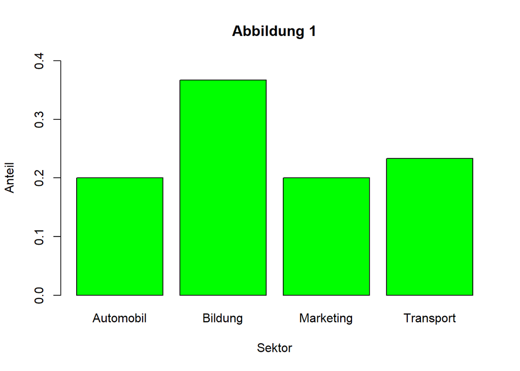

```r
barplot(prop.table(table(Sector)), main = "Abbildung 1", col = "green",
names.arg = c("Automobil", "Bildung", "Marketing", "Transport"),
xlab = "Sektor", ylab = "Anteil", ylim = c(0, 0.4))
```

Der Befehl wird ergänzt durch eine Überschrift (`main`), Farbe (`col`), Bezeichnung der Merkmalsausprägungen (`names.arg`), Achsenbezeichnungen für x- und y-Achse (`xlab` und `ylab`) und die Skalierung der y-Achse (`ylim`). Die y-Achse sollte so skaliert sein, dass der größte Wert der Skala (hier 0.4) größer ist als die größte relative Häufigkeit (hier ca. 0.37 für Bildung). Zahlenwerte könnten im Barplot mit `text()` ergänzt werden.

Die Ausprägung Bildung ist hier offensichtlich der **Modus**, d.h., der Sektor Bildung hat mit ca. 37% die größte relative Häufigkeit.

### Kontingenztabelle

Bislang haben wir eindimensionale qualitative Daten (also nur ein Merkmal) betrachtet. Nun gehen wir zu zweidimensionalen qualitativen Daten (zwei Merkmale) über. Zweidimensionale qualitative Daten werden mit einer Kontingenztabelle dargestellt. Präziser: Eine Kontingenztabelle stellt die gemeinsame Verteilung von zwei qualitativen Merkmalen dar. Der Wert $n_{ij}$ (mit $i$ als Zeile und $j$ als Spalte) in der Tabelle stellt die gemeinsame absolute Häufigkeit für $X = X_i$ und $Y = Y_j$ dar, also $n_{ij}$ = absH($X = X_i$ & $Y = Y_j$). Der Befehl für eine Kontingenztabelle ist wieder `table()`, nur das jetzt zwei Merkmale angegeben werden.

```r
table(Gender, Sector) # Kontingenztabelle für Gender und Sector
```

```
##         Sector
## Gender   automobile education marketing transport
##   female          1         8         2         3
##   male            5         3         4         4
```

Üblicherweise werden Kontingenztabellen mit **Randverteilungen** dargestellt.

```r
addmargins(table(Gender, Sector)) # mit Randverteilungen
```

```
##         Sector
## Gender   automobile education marketing transport Sum
##   female          1         8         2         3  14
##   male            5         3         4         4  16
##   Sum             6        11         6         7  30
```

In der Kontingenztabelle oben sind neben der gemeinsamen Verteilung auch die Randverteilungen für `Gender` und `Sector` mit `addmargins()` dargestellt. Aus der gemeinsamen Verteilung ist z.B. ersichtlich, dass 5 Befragte Männer sind und im Auto-Sektor arbeiten. 8 Befragte sind Frauen und arbeiten im Bildungssektor. Aus den Randverteilungen ergibt sich z.B., dass 11 Befragte im Bildungssektor arbeiten und 16 Männer an der Befragung teilgenommen haben.

Bislang war die Kontingenztabelle über die absoluten Häufigkeiten definiert. Wir können die Kontingenztabelle aber auch leicht mit `prop.table()` in relativen Häufigkeiten schreiben:

```r
addmargins(prop.table(table(Gender, Sector))) # greift auf table() zu
```

```
##         Sector
## Gender   automobile education marketing transport      Sum
##   female   0.033333  0.266667  0.066667  0.100000 0.466667
##   male     0.166667  0.100000  0.133333  0.133333 0.533333
##   Sum      0.200000  0.366667  0.200000  0.233333 1.000000
```

Interpretation, z.B.: 10% aller Teilnehmer sind Männer und arbeiten im Bildungsbereich.

### Bedingte relative Häufigkeiten

Häufig ist es notwendig, bedingte relative Häufigkeiten zu bestimmen. Wir schreiben für die relative Häufigkeit von A unter der Bedingung B: relH(A|B). Zum Beispiel könnte von Interesse sein, wie viel Prozent aller Frauen im Bildungssektor arbeiten. Mit Blick auf die Kontingenztabelle oben ergibt sich: relH(education|female) = 8/14 = 57%. Oder: Wie viel Prozent aller Mitarbeiter im Transportsektor sind Frauen? Hier: relH(female|transport) = 3/7 = 43%. Wir können die bedingten relativen Häufigkeiten auch ausgeben lassen. Man muss dabei entscheiden, ob Zeile (hier: `Gender`) oder Spalte (hier: `Sector`) die Bedingung sein soll.

```r
addmargins(prop.table(table(Gender, Sector), 1)) # 1 = Zeile als Bedingung
```

```
##         Sector
## Gender   automobile education marketing transport      Sum
##   female   0.071429  0.571429  0.142857  0.214286 1.000000
##   male     0.312500  0.187500  0.250000  0.250000 1.000000
##   Sum      0.383929  0.758929  0.392857  0.464286 2.000000
```

Die Summe der bedingten relativen Häufigkeiten ist 1. Interpretation, z.B.: 57% aller Frauen arbeiten im Bildungssektor, aber nur 7% der Frauen sind im Auto-Sektor tätig.

```r
addmargins(prop.table(table(Gender, Sector), 2)) # 2 = Spalte als Bedingung
```

```
##         Sector
## Gender   automobile education marketing transport     Sum
##   female    0.16667   0.72727   0.33333   0.42857 1.65584
##   male      0.83333   0.27273   0.66667   0.57143 2.34416
##   Sum       1.00000   1.00000   1.00000   1.00000 4.00000
```

Interpretation, z.B.: 67% aller Beschäftigten im Marketing sind Männer, aber nur 33% aller Beschäftigten im Marketing sind Frauen. Wir stellen hier fest, dass sich die bedingten relativen Häufigkeiten z.T. deutlich unterscheiden. Dies deutet darauf hin, dass beide Merkmale (`Gender` und `Sector`) nicht unabhängig voneinander sind (vgl. Definition von statistischer Unabhängigkeit).

#### Exkurs: Abbildungen für Kontingenztabellen

Üblicherweise stellt man auch die bedingten relativen Häufigkeiten mit einem Barplot (Säulendiagramm) dar. Betrachten wir das Beispiel mit `Gender` und `Sector`.

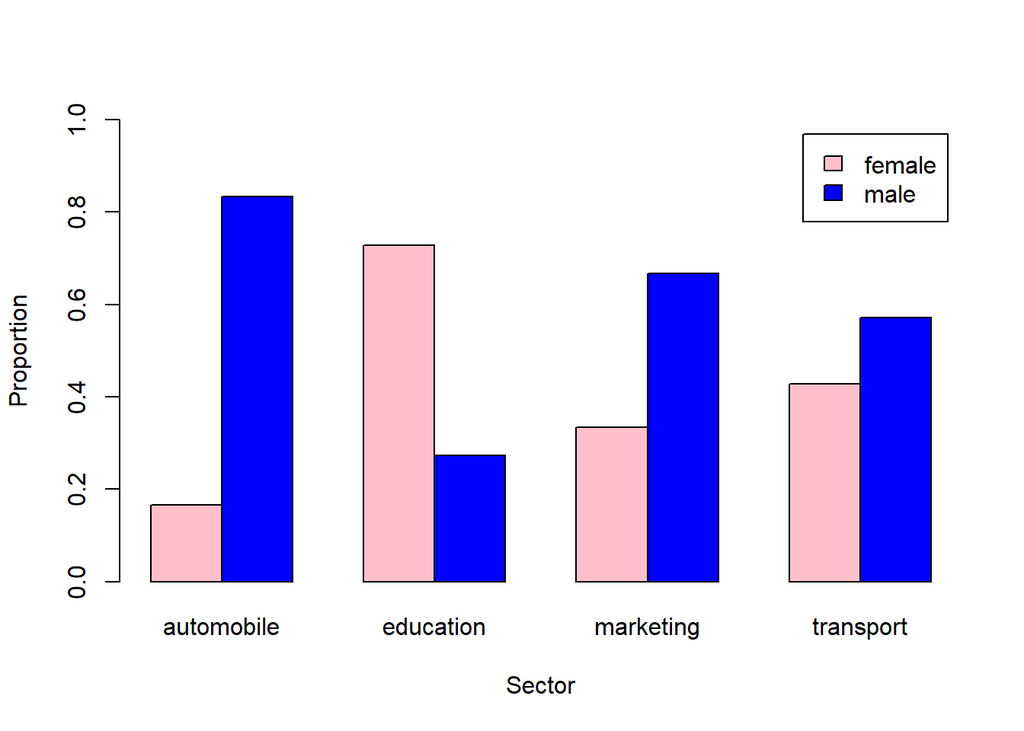

```r
barplot(prop.table(table(Gender, Sector), 2), xlab = "Sector", ylab = "Proportion",
        ylim = c(0, 1), beside = TRUE, col = c("pink", "blue"),
        legend = row.names(table(Gender, Sector)))
```

Die Legende wird mit `legend` angegeben, wobei wir mit `row.names` auf die Zeilennamen der Kontingenztabelle für `Gender` und `Sector` (vgl. oben) zugreifen. Die Säulen für die bedingten relativen Häufigkeiten werden nebeneinander (`beside`) dargestellt und nicht übereinander (das ist Geschmackssache). Für jede Ausprägung von `Sector` addieren sich die Säulen (relative Häufigkeiten) zu 100%. Offensichtlich unterscheiden sich die bedingten Verteilungen zwischen den Sektoren. Während im Auto-Sektor das Verhältnis von Männern zu Frauen ca. 80 zu 20 ist, ist es im Bildungssektor ca. 30 zu 70. Damit wird offensichtlich, dass `Gender` und `Sector` nicht unabhängig voneinander sind (also hier das Geschlecht einen Effekt auf die Berufswahl hat).

## Quantitative Daten (alle Module)

In diesem Kapitel beschäftigen wir uns mit Verteilungen von quantitativen Daten und mit Lage- und Streuungsmaßen.

### Darstellung von Verteilungen

Zur graphischen Darstellung der Verteilung eines quantitativen Merkmals werden Histogramm und Verteilungsfunktion genutzt.

#### Histogramm

Für die Darstellung einer Verteilung im Histogramm werden Klassen der Breite $\triangle_i$ definiert. Pro Klasse $i = 1, ..., k$ wird dann die absolute Häufigkeit $n_i$ (“frequency”) an Beobachtungen in dieser Klasse ausgegeben. Im Histogramm sind dann auf der x-Achse die Größenklassen des Merkmals (mit Breite $\triangle_i$) und auf der y-Achse die Zahl der Beobachtungen pro Klasse ($n_i$) dargestellt. Es gilt $\sum_{i=1}^{k}n_i=n$.

Anhand des Histogramms kann die **Verteilung** analysiert werden hinsichtlich der Kriterien:

- Form wie Symmetrie bzw. Asymmetrie (z.B. links- oder rechtssteil)
- Modus (Klasse mit der größten relativen Häufigkeit)
- Ausreißer (auffällige Beobachtungen)

Betrachten wir ein Beispiel:

```r
setwd("C:/Users/sturm/Desktop/dataR")   # setze das Arbeitsverzeichnis
s.data <- read.csv("student.csv")
# s.data <- read.csv("https://raw.githubusercontent.com/bodosturm/dataR/main/student.csv")
s.data[1:2, 1:8]; dim(s.data)
```

|  | fem | age | height | weight | shoe | sport | veg_fruits | income |
| --- | --- | --- | --- | --- | --- | --- | --- | --- |
| 1 | 0 | 20 | 175 | 58 | 41 | 3 | 0 | 300 |
| 2 | 1 | 20 | 168 | 63 | 39 | 1 | 5 | 700 |

```
## [1] 711  10
```

Bevor wir ein Histogramm erstellen, ist `summary()` nützlich. Dieser Befehl liefert sechs Werte (Min, Q<sub>1</sub>, Median, arithmetisches Mittel, Q<sub>3</sub>, Max) und zeigt an, ob es NAs (not available, fehlende Werte) gibt.

```r
summary(s.data$age) # summary für age
```

```
##    Min. 1st Qu.  Median    Mean 3rd Qu.    Max.     NAs
##    15.0    21.0    23.0    23.3    25.0    88.0       4
```

Offensichtlich gibt es hier Werte (15, 88), die vermutlich fehlerhafte Eingaben sind. Betrachten wir das Histogramm:

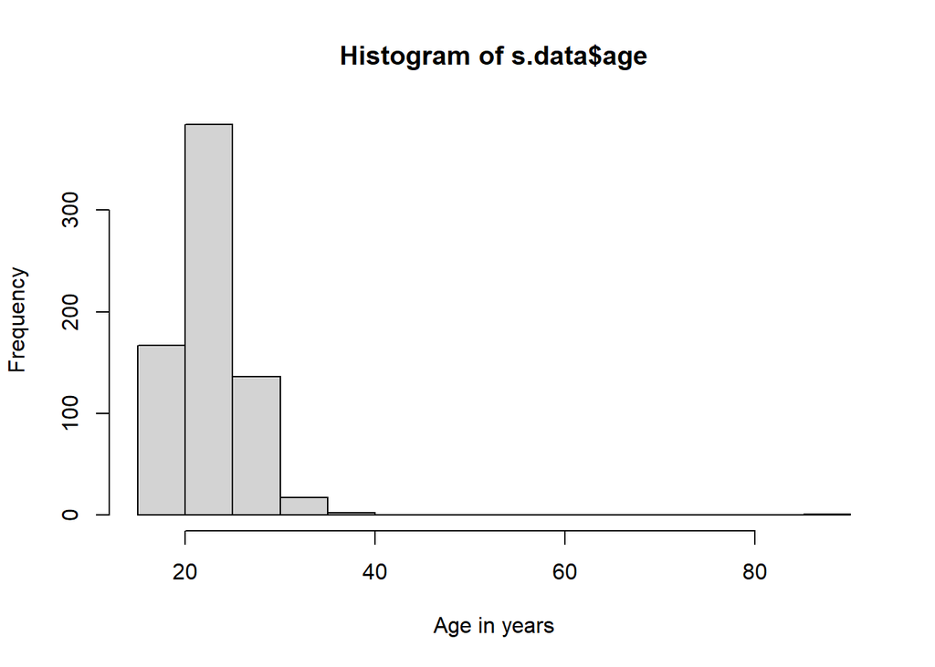

```r
hist(s.data$age, xlab = "Age in years") # Standardhistogramm mit n_i
```

Die Klassenbreite (hier $\triangle_i=5$) wird automatisch gewählt. Eine Beobachtung in der letzten Klasse (85, 90] ist offensichtlich ein Fehler und sollte nicht weiter berücksichtigt werden (den Wert 15 in der ersten Klasse [15, 20] lassen wir dagegen zu).

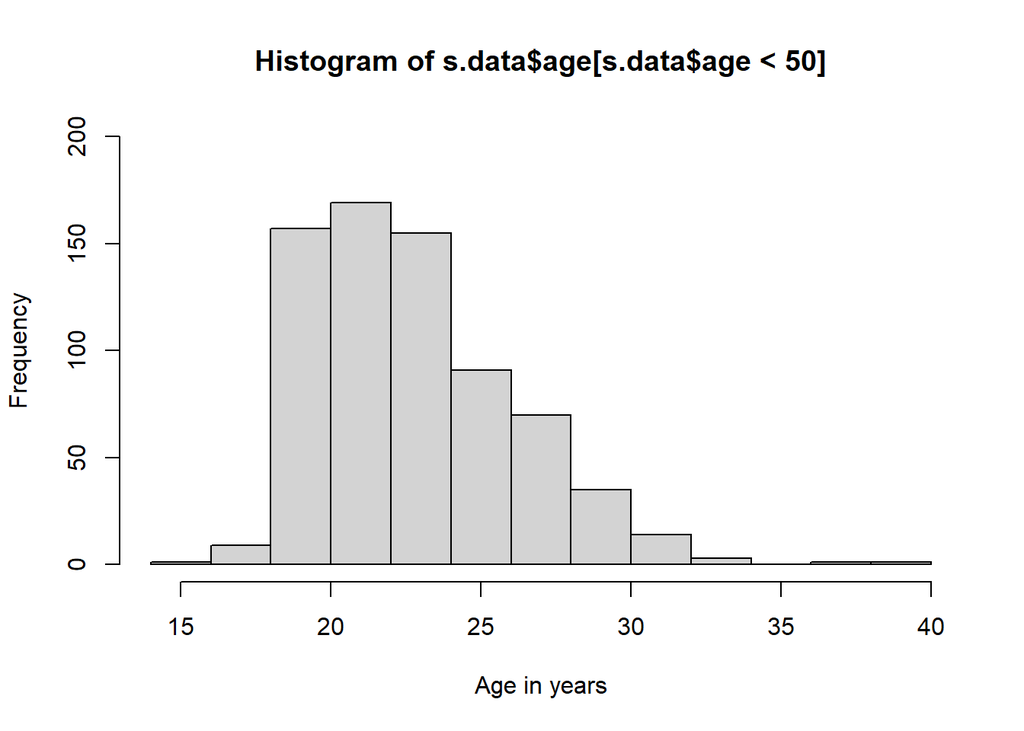

```r
hist(s.data$age[s.data$age < 50], xlab = "Age in years", ylim = c(0, 200)) # Histogramm für age < 50
```

Die Klassenbreite ist nun $\triangle_i=2$. Die Verteilung ist nicht symmetrisch, sondern linkssteil (bzw. skewed to the right). Die modale Klasse ist (20, 22] Jahre. Es gibt zwei Ausreißer am rechten Rand der Verteilung (Alter > 35 Jahre).

R speichert eine Reihe von Informationen zu einem Histogramm ab, wenn man mit `hist()` ein Objekt definiert. Ein paar Informationen zum Histogramm von `age`:

```r
H <- hist(s.data$age[s.data$age < 50], plot = FALSE) # Definiere Objekt, keine Darstellung
H$breaks       # Klassengrenzen mit (Untergrenze, Obergrenze], aber 1. Klasse mit []
```

```
##  [1] 14 16 18 20 22 24 26 28 30 32 34 36 38 40
```

```r
H$counts       # Ausgabe Beob. n_i pro Klasse i
```

```
##  [1]   1   9 157 169 155  91  70  35  14   3   0   1   1
```

```r
sum(H$counts)  # Zahl der Beob.
```

```
## [1] 706
```

```r
table(s.data$age[s.data$age < 50] > 20 & s.data$age[s.data$age < 50] <= 22) # Beob. in (20, 22]
```

```
##
## FALSE  TRUE
##   537   169
```

Die Klassengrenzen des Histogramms können leicht geändert werden.

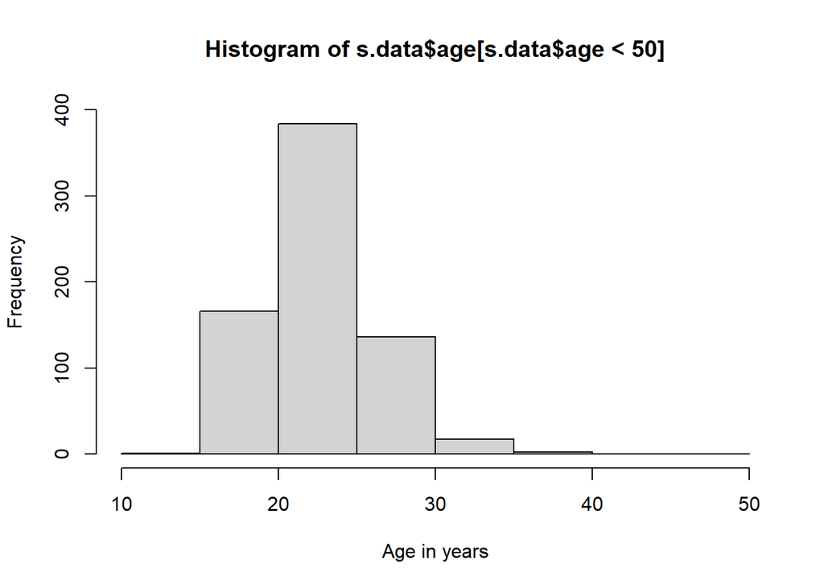

```r
hist(s.data$age[s.data$age < 50], breaks = seq(10, 50, 5),
     ylim = c(0, 400), xlab = "Age in years")  # Klassengrenzen definieren
```

Wenn man die Klassengrenzen selbst definiert, ist darauf zu achten, dass alle Beobachtungen von den Klassen auf der x-Achse erfasst werden (sonst gibt es eine Fehlermeldung).

Ein weiteres Beispiel: Wir wollen 1000 Zufallszahlen aus der N(0,1)-Verteilung (auch als Standardnormalverteilung bezeichnet) ziehen und die Verteilung mit Hilfe eines Histogramms graphisch darstellen. Der Zufallszug wird mit `rnorm()` durchgeführt. Dabei steht `r` für “random” und `norm` für “normal distribution”. Um diesen Zufallszug reproduzierbar zu machen, setzen wir vorab `set.seed()`. Dabei ist die im Befehl verwendete Zahl beliebig, es muss nur die gleiche sein wie im zu reproduzierenden Befehl (hier die 4).

```r
set.seed(4)  # sichert Reproduzierbarkeit des Zufallszugs
x <- rnorm(1000, mean = 0, sd = 1)  # 1000 Zufallszahlen aus N(0,1)
x[1:5]       # die ersten 5 Werte von x
```

```
## [1]  0.21675 -0.54249  0.89114  0.59598  1.63562
```

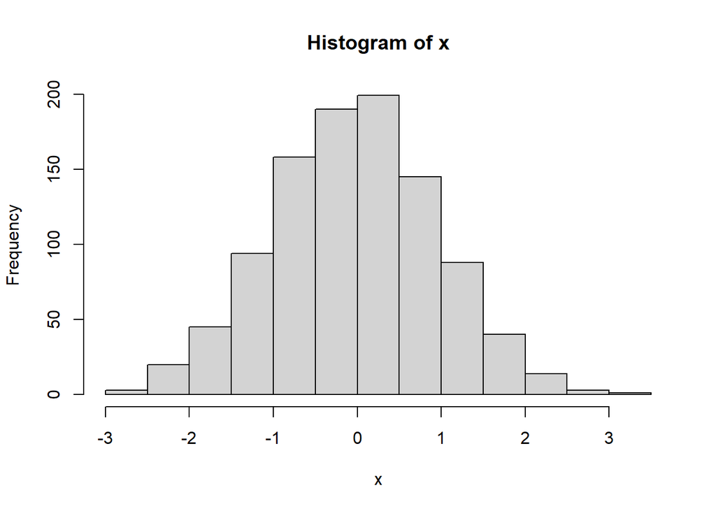

```r
hist(x)
```

```r
summary(x)   # arithm. Mittel ist approx. 0
```

```
##    Min. 1st Qu.  Median    Mean 3rd Qu.    Max.
## -2.8396 -0.6661 -0.0398 -0.0344  0.6350  3.1742
```

```r
sd(x)        # Standardabweichung, sollte nah an 1 sein
```

```
## [1] 0.9693
```

Das Histogramm ist symmetrisch um Null (= Modus) und hat eine Glockenform. Es gibt keine Ausreißer.

Wenn eine Variable $X$ einer Normalverteilung folgt, schreibt man dafür $X \sim N(\mu, \sigma)$ mit $\mu$ als arithmetisches Mittel und $\sigma$ als Standardabweichung. Für die Standardnormalverteilung gilt dann $Z \sim N(0,1)$. Die Standardabweichung ist ein Maß für die Streuung der Beobachtungen (vgl. unten).

Eine wichtige Regel für die Verteilung von Zufallsvariablen aus $N(\mu, \sigma)$ ist die **“Empirical Rule”**. Diese Regel besagt: Bei einer normalverteilten Zufallsvariablen liegen im Intervall $\mu \pm 2 \sigma$ ca. 95% der Beobachtungen.

Wir betrachten hier unseren Vektor `x`. Die logische Abfrage und Auswertung erfolgt über `table()`.

```r
prop.table(table((x <= 2) & (x >= -2)))  # Abfrage einer Bedingung
```

```
##
## FALSE  TRUE
## 0.041 0.959
```

Eine solche logische Abfrage kann sehr nützlich sein. Wir erzeugen mit der Abfrage ein qualitatives Merkmal mit den Ausprägungen `TRUE` und `FALSE` und dieses wird mit `table()` ausgewertet.

#### Verteilungsfunktion

Die Verteilungsfunktion der Variablen $X$, $F(x)$, ist definiert als $F(x) = relH(X \leq x)$. Sie gibt also für den Wert $x$ der Variablen $X$ an, wie viel Prozent der Beobachtungen von $X$ kleiner oder gleich $x$ sind. Betrachten wir die Verteilungsfunktion für den Vektor `x` (vgl. Zufallsexperiment oben). Der Befehl lautet `plot.ecdf()`, wobei `ecdf` für “empirical cumulative distribution function” steht.

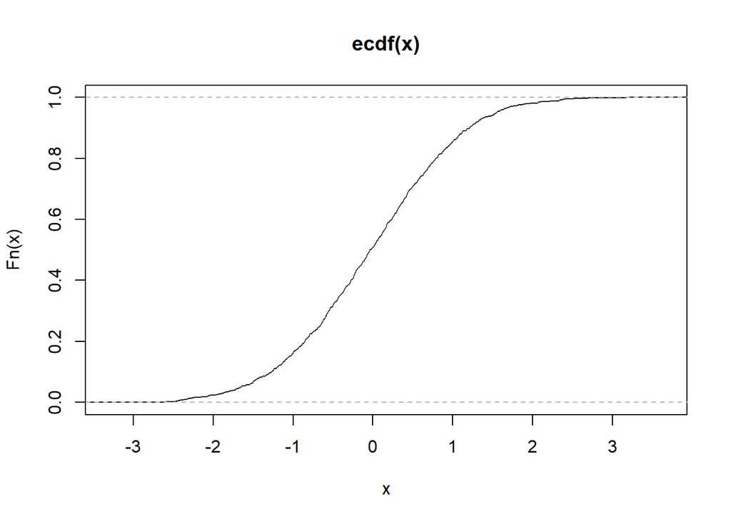

```r
plot.ecdf(x)   # Plot der ecdf
```

Betrachten wir $F(x)$ für einen bestimmten Wert von $x$. Es sei $x = -1$.

```r
F_x <- ecdf(x) # Definition von F
F_x(-1)        # Abfrage des Funktionswertes von F
```

```
## [1] 0.162
```

```r
prop.table(table(x <= -1)) # Alternative zur Berechnung von F
```

```
##
## FALSE  TRUE
## 0.838 0.162
```

Interpretation: 16.2% der Beobachtungen von $X$ sind kleiner oder gleich -1 (das kann man auch oben in der Abbildung ablesen). Damit sind 83.8% der Beobachtungen von $X$ größer als -1. Die Verteilungsfunktion wird häufig dann benutzt, wenn man mehrere Verteilungen vergleichen möchte.

Betrachten wir ein Beispiel.

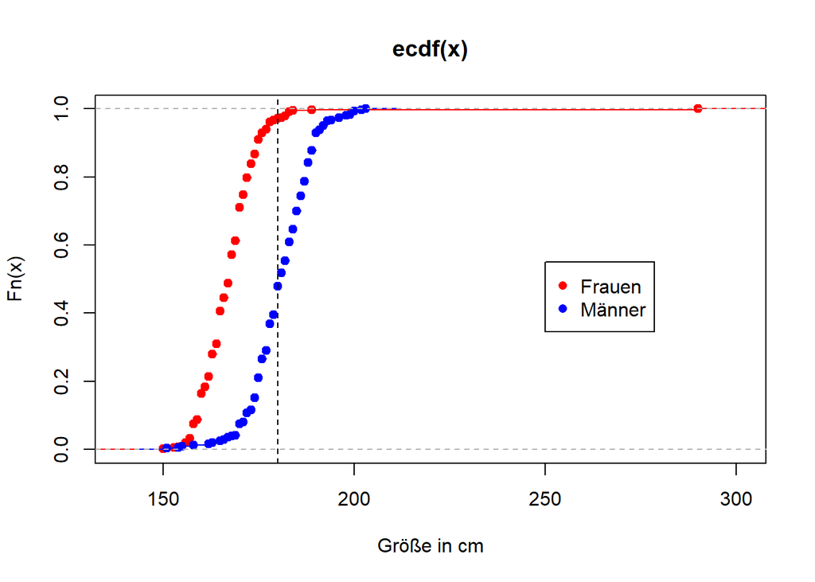

```r
setwd("C:/Users/sturm/Desktop/dataR")        # setze das Arbeitsverzeichnis
s.data <- read.csv("student.csv")
# s.data <- read.csv("https://raw.githubusercontent.com/bodosturm/dataR/main/student.csv")
plot.ecdf(s.data$height[s.data$fem == 1], col = "red", xlab = "Größe in cm") # Frau = rot
F_weight_male <- ecdf(s.data$height[s.data$fem == 0])               # F für Mann
lines(F_weight_male, col = "blue")            # plot F für Männer = blau
abline(v = 180, lty = 2)                      # vertikale Linie bei 180
legend(250, 0.55, pch = c(16,16), col = c("red","blue"), c("Frauen","Männer")) # Legende
```

Im Plot oben wird zuerst die Verteilungsfunktion der Frauen gezeichnet mit `plot.ecdf()`. Dann wird die Verteilungsfunktion der Männer mit `ecdf()` erzeugt und zusätzlich mit `lines()` über den Plot für die Frauen gelegt. In der Legende mit `legend()` wird das Symbol mit `pch` definiert (hier `16` für einen Punkt). Da es zwei Ausprägungen gibt (für Frauen und Männer), werden die Angaben in der Legende mit Vektoren über `c()` definiert.

#### Quartile und Quantile

Es gibt **drei Quartile**, Q<sub>1</sub>, Q<sub>2</sub> und Q<sub>3</sub>, die eine geordnete Reihe von Zahlen in vier möglichst gleich große Abschnitte aufteilen. Das zweite Quartil, Q<sub>2</sub>, ist die Zahl, für die gilt, dass 50% der Beobachtungen kleiner oder gleich Q<sub>2</sub> sind und 50% größer oder gleich Q<sub>2</sub>. Q<sub>2</sub> wird auch **Median** genannt. Entsprechend gilt für Q<sub>1</sub> (Q<sub>3</sub>), dass 25% (75%) der Beobachtungen kleiner oder gleich Q<sub>1</sub> (Q<sub>3</sub>) sind und 75% (25%) größer oder gleich Q<sub>1</sub> (Q<sub>3</sub>).

Betrachten wir als Beispiel die Werte für die Körpergröße der Studierenden getrennt nach Frauen und Männern.

```r
summary(s.data$height[s.data$fem == 1 & s.data$height < 250])
```

```
##    Min. 1st Qu.  Median    Mean 3rd Qu.    Max.     NAs
##     150     163     168     167     171     189       4
```

```r
summary(s.data$height[s.data$fem == 0 & s.data$height < 250])
```

```
##    Min. 1st Qu.  Median    Mean 3rd Qu.    Max.     NAs
##     151     176     181     181     187     203       3
```

Interpretation: 25% aller Frauen sind 163 cm groß oder kleiner. Bei den Männern sind die 25% kleinsten 176 cm groß oder kleiner.

Man kann das Konzept der Quartile verallgemeinern zum Konzept der Quantile. Ein **q-Quantil** mit $0<q<1$ ist die Zahl $x_{[q]}$, für die gilt $q*100%$ $\leq$ ${x_{[q]}}$ und $(1-q)*100%$ $\geq$ $x_{[q]}$. Zum Beispiel ist das 10%-Quantil der Variable $X$, $x_{[0.1]}$, die Zahl, für die gilt: 10% der Beobachtungen von $X$ sind kleiner oder gleich $x_{[0.1]}$ und 90% der Beobachtungen von $X$ sind größer oder gleich $x_{[0.1]}$. Der Befehl `quantile()` liefert in R die Quantile.

```r
quantile(s.data$height[s.data$fem == 1 & s.data$height < 250], na.rm = TRUE) # NA raus, vgl. bei mean()
```

```
##     0%    25%    50%    75%   100%
## 150.00 163.00 168.00 171.25 189.00
```

```r
quantile(s.data$height[s.data$fem == 1 & s.data$height < 250], seq(0, 1, 0.1), na.rm = TRUE)
```

```
##   0%  10%  20%  30%  40%  50%  60%  70%  80%  90% 100%
##  150  160  162  164  165  168  169  170  172  175  189
```

Interpretation, z.B.: 10% aller Frauen sind 160 cm groß oder kleiner. Die 10% größten Frauen sind mindestens 175 cm groß.

### Lagemaße

Lagemaße geben Auskunft über die typische Beobachtung einer Verteilung. Die zwei bekanntesten Lagemaße sind das arithmetische Mittel und der Median.

#### Arithmetisches Mittel

Das arithmetische Mittel ist das “klassische” Lagemaß (vgl. zu Eigenschaften das Lehrbuch). Es ist definiert als die Summe aller Merkmalsausprägungen geteilt durch die Zahl der Merkmalsausprägungen:

$\bar{x}=\frac{1}{n}\sum_{i=1}^nx_{i}$

Als Beispiel betrachten wir die ganzen Zahlen von 1 bis 100.

```r
x <- 1:100     # die ganzen Zahlen von 1 bis 100
sum(x)/length(x)
```

```
## [1] 50.5
```

```r
mean(x)        # Funktion für das arithm. Mittel
```

```
## [1] 50.5
```

```r
summary(x)     # weitere Lagemaße neben dem arithm. Mittel
```

```
##    Min. 1st Qu.  Median    Mean 3rd Qu.    Max.
##     1.0    25.8    50.5    50.5    75.2   100.0
```

Wenn eine Zahlenreihe NAs enthält, müssen diese vor der Berechnung des arithmetischen Mittels mit `mean()` (mit `na.rm`) entfernt werden. Bei `summary()` ist dies nicht nötig. Der folgende Befehl liefert das arithmetische Mittel der Körpergröße für alle Frauen (mit und ohne den Aureißer bei 290 cm).

```r
summary(s.data$height[s.data$fem == 1])
```

```
##    Min. 1st Qu.  Median    Mean 3rd Qu.    Max.     NAs
##     150     163     168     168     172     290       4
```

```r
mean(s.data$height[s.data$fem == 1 & s.data$height < 250], na.rm = TRUE)
```

```
## [1] 167.46
```

```r
summary(s.data$height[s.data$fem == 1 & s.data$height < 250], na.rm = TRUE)
```

```
##    Min. 1st Qu.  Median    Mean 3rd Qu.    Max.     NAs
##     150     163     168     167     171     189       4
```

#### Median

Der Median ist das 50%-Quantil (oder auch 2. Quartil, Q<sub>2</sub> oder $x_{[0.5]}$ genannt). In der geordneten Reihe der Beobachtungen liegt der Median genau in der Mitte. Er wird als Lagemaß bei nicht symmetrischen Verteilungen oder bei Verteilungen mit Ausreißern verwendet.

Betrachten wir die folgenden Beispiele:

```r
x1 <- c(1:5, 10)             # definiere x1
x2 <- c(1:5, 1000)           # definiere x2
x3 <- c(1:6, 10)             # definiere x3
x4 <- c(1:6, 1000)           # definiere x4
median(x1); median(x2); median(x3); median(x4)
```

```
## [1] 3.5
```

```
## [1] 3.5
```

```
## [1] 4
```

```
## [1] 4
```

Ein Beispiel für eine linkssteile Verteilung (skewed to the right) ist die $\chi^2$-Verteilung (gesprochen “Chi-Quadrat”) mit 5 Freiheitsgraden (df). Hierfür werden 5 Zufallsvariablen aus der N(0,1)-Verteilung quadriert und aufsummiert. Hier ist der Median deutlich kleiner als das arithmetische Mittel, welches nach rechts verzerrt ist.

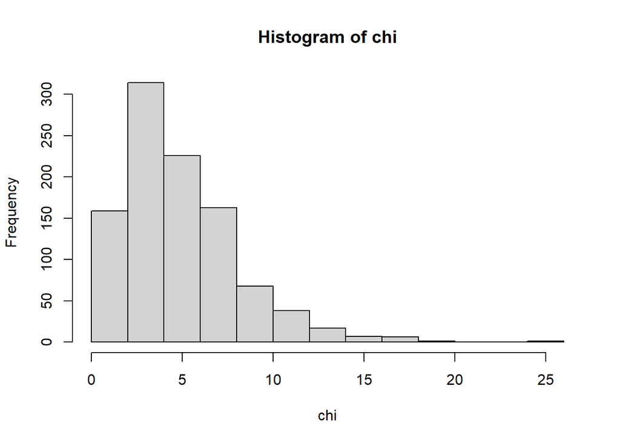

```r
set.seed(4)              # sichert Reproduzierbarkeit
chi <- rchisq(1000, 5)   # 1000 Zufallszahlen aus der Chi2 mit df = 5
hist(chi)                # Histogramm von chi
```

```r
summary(chi)
```

```
##    Min. 1st Qu.  Median    Mean 3rd Qu.    Max.
##    0.15    2.63    4.20    4.89    6.47   25.35
```

Der Median ist robust bzgl. der Schiefe der Verteilung und der Existenz von Ausreißern. Das arithmetische Mittel wird hingegen stark von der Schiefe der Verteilung bzw. von der Existenz von Ausreißern beeinflusst. Für linkssteile Verteilungen (skewed to the right) gilt $\bar{x} > x_{[0.5]}$ und für rechtssteile (skewed to the left) Verteilungen $\bar{x} < x_{[0.5]}$.

### Streuungsmaße

Streuungsmaße werden benutzt, um die Variabilität von Merkmalsausprägungen zu messen. Wir betrachten hier drei Streuungsmaße: (1) Interquartilsabstand (IQR = Interquartile Range), (2) Varianz und (3) Standardabweichung.

#### IQR

Der IQR ist definiert als $IQR = Q_3 - Q_1$. Er gibt also die Breite des Intervalls an, in dem sich die mittleren 50% aller Beobachtungen befinden. Bei einem größeren IQR streuen die mittleren 50% der Daten stärker. Man kann den IQR z.B. über `summary()` bestimmen oder auch über `IQR()`. Durch Unterschiede bei der Approximation kann es hier zu leicht unterschiedlichen Angaben kommen.

```r
summary(chi) # IQR = Q3 - Q1 = 6.47 - 2.63 = 3.84, leichte Abweichung zu IQR()
```

```
##    Min. 1st Qu.  Median    Mean 3rd Qu.    Max.
##    0.15    2.63    4.20    4.89    6.47   25.35
```

```r
IQR(chi)     # leichte Abweichung zu summary()
```

```
## [1] 3.8389
```

Man kann den IQR auch graphisch mit Hilfe der Verteilungsfunktion darstellen.

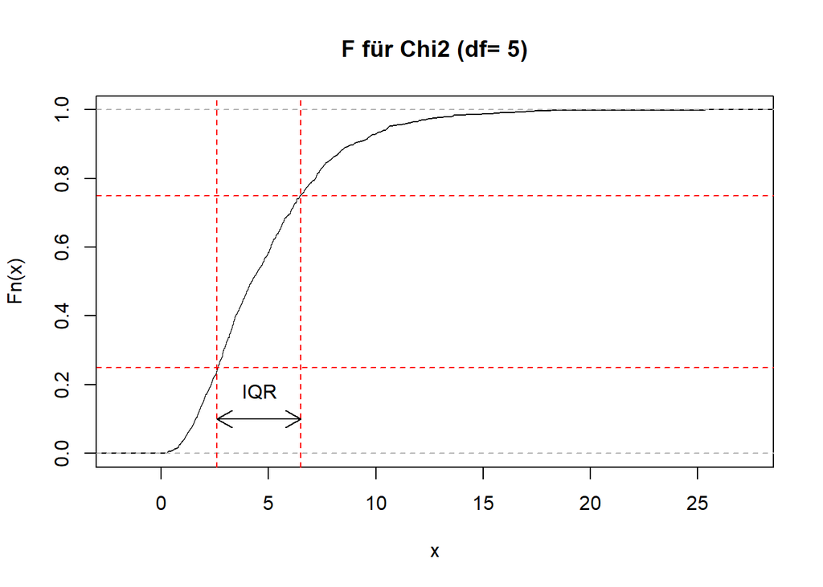

```r
plot.ecdf(chi, main = "F für Chi2 (df= 5)")         # Plot der ecdf von chi
abline(h = c(0.25, 0.75), lty = 2, col = "red")     # Hilfslinie horizontal
abline(v = c(2.6, 6.5), lty = 2, col = "red")       # Hilfslinie vertikal
arrows(2.6, 0.1, 6.5, 0.1, length = 0.15, code = 3) # Hilfslinie Pfeil
text(4.6, 0.18, "IQR")                              # Text
```

#### Varianz

Die Varianz der Stichprobe, $s^2$, ist die mittlere quadrierte Abweichung der $n$ Elemente in der Stichprobe von ihrem arithmetischen Mittel $\bar{x}$, d.h.

$s^{2}=\frac{1}{n}\sum_{i=1}^n(x_{i}-\bar{x})^{2}$

Die Varianz der Grundgesamtheit, $\sigma^{2}$, ist die mittlere quadrierte Abweichung der $N$ Elemente in der Grundgesamtheit von ihrem arithmetischen Mittel $\mu$, d.h.

$\sigma^{2}=\frac{1}{N}\sum_{i=1}^N(x_{i}-\mu)^{2}$

Üblicherweise ist $\sigma^{2}$ unbekannt.

Daher wird normalerweise die Varianz $\sigma^{2}$ geschätzt mit

$\widehat{\sigma}^{2}=\frac{n}{n-1}s^2=\frac{1}{n-1}\sum_{i=1}^n(x_{i}-\bar{x})^{2}$

Man kann zeigen, dass unter bestimmten Bedingungen $\widehat{\sigma}^{2}$ eine erwartungstreue und konsistente Schätzung für $\sigma^{2}$ ist (vgl. Lehrbuch). Wir bezeichnen $\widehat{\sigma}^{2}$ daher auch als geschätzte Varianz der Grundgesamtheit. Sie wird mit `var()` berechnet. R betrachtet also Daten immer als Stichprobeninformationen, mit denen man etwas über die Grundgesamtheit lernen möchte.

Betrachten wir ein einfaches Beispiel.

```r
U <- c(1:10, 25, 40) # Definiere das Objekt U
var(U)               # geschätzte Varianz der Grundgesamtheit
```

```
## [1] 128.18
```

```r
n <- length(U)
sum((U - mean(U))^2)/(n-1)
```

```
## [1] 128.18
```

#### Standardabweichung

Die Standardabweichung der Grundgesamtheit, $\sigma$, ist die Wurzel der Varianz, d.h.

$\sigma=\sqrt{\frac{1}{N}\sum_{i=1}^N(x_{i}-\mu)^{2}}$

Da $\sigma$ normalerweise unbekannt ist, wird diese Standardabweichung geschätzt mit

$\widehat{\sigma}=\sqrt{(\frac{n}{n-1})}s=\sqrt{\frac{1}{n-1}\sum_{i=1}^n(x_{i}-\bar{x})^{2}}$

Wir bezeichnen $\widehat{\sigma}$ auch als **geschätzte Standardabweichung der Grundgesamtheit**. $\widehat{\sigma}$ ist unter bestimmten Bedingungen (vgl. Lehrbuch) ein erwartungstreuer und konsistenter Schätzwert für $\sigma$.

Für das Beispiel oben zur Varianz ist:

```r
sd(U) # geschätzte Standardabweichung der Grundgesamtheit
```

```
## [1] 11.322
```

```r
sqrt(sum((U - mean(U))^2)/(n-1))
```

```
## [1] 11.322
```

### Boxplot

Ein Boxplot ist eine kompakte Methode, um die Verteilung eines quantitativen Merkmals darzustellen. Ein Boxplot beinhaltet folgende Informationen: Minimum, Q<sub>1</sub>, Median, Q<sub>3</sub>, Maximum und ggf. Ausreißer. Neben der Spannweite (range = max - min) wird damit auch der IQR dargestellt und man hat die Information, in welchem Intervall die mittleren 50% der Beobachtungen liegen und wie diese Werte verteilt sind. Außerdem liefert der Median eine Information über die Lage der Verteilung. Häufig werden Boxplots genutzt, um die Verteilung eines quantitativen Merkmals für unterschiedliche Ausprägungen eines qualitativen Merkmals darzustellen.

Ein Boxplot besteht zunächst aus einer “Box”, mit Q<sub>1</sub> als untere und Q<sub>3</sub> als obere Grenze. Dazu ist der Median als Linie eingezeichnet. Außerhalb der Box liegen die sog. “Whisker”, welche die kleinste bzw. größte Beobachtung, die keine Ausreißer sind, darstellen. Alle Beobachtungen, die jenseits der Whisker liegen, werden mit einem Punkt als Ausreißer dargestellt. Die Position der Whisker bestimmt sich folgendermaßen:

- Wenn: größte Beobachtung $>$ $Q_{3} + 1.5*IQR$, dann liegt der obere Whisker bei der größten Beobachtung innerhalb von $Q_{3} + 1.5*IQR$. Wenn: größte Beobachtung $\leq$$Q_{3} + 1.5*IQR$, dann liegt der obere Whisker bei der größten Beobachtung.
- Wenn: kleinste Beobachtung $<$ $Q_{1} - 1.5*IQR$, dann liegt der untere Whisker bei der kleinsten Beobachtung innerhalb von $Q_{1} - 1.5*IQR$. Wenn: kleinste Beobachtung $\geq$$Q_{1} - 1.5*IQR$, dann liegt der untere Whisker bei der kleinsten Beobachtung.

Der Befehl zur Erstellung eines Boxplots ist `boxplot()`. Betrachten wir für die Variable `height` (für Werte mit `height<250`) oben den Boxplot:

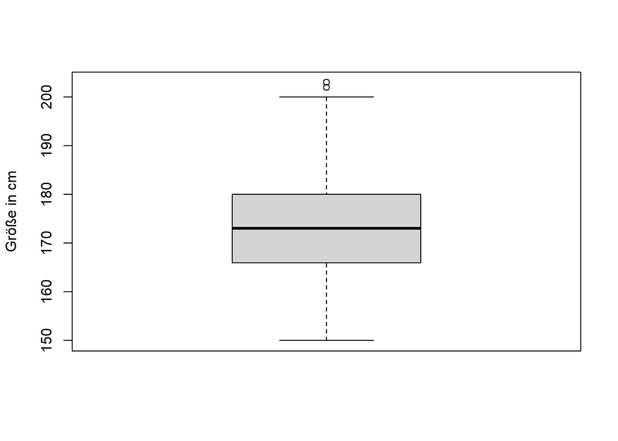

```r
boxplot(s.data$height[s.data$height < 250], ylab = "Größe in cm")
```

Offensichtlich ist es interessanter, die Verteilung von `height` für Männer und Frauen getrennt zu betrachten. Hierzu müssen wir das qualitative Merkmal `fem` mit dem `~`-Zeichen benutzen.

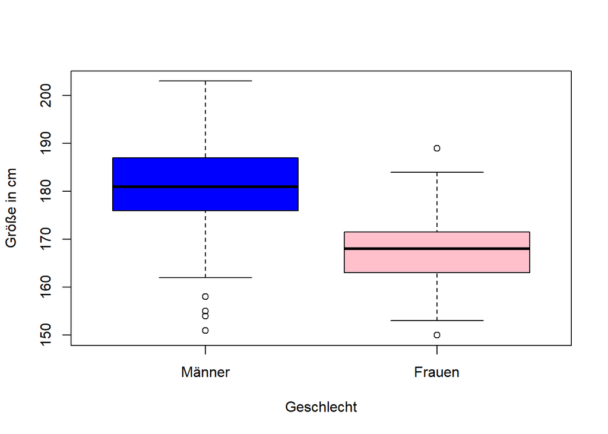

```r
boxplot(s.data$height[s.data$height < 250] ~ s.data$fem[s.data$height < 250],
        xlab = "Geschlecht", col = c("blue", "pink"),
        names = c("Männer", "Frauen"), ylab = "Größe in cm")
```

Der Median der Männer liegt bei 181 cm und der Median der Frauen bei 168 cm. Hier ist der IQR bei Männern etwas größer als bei Frauen (ebenso die Spannweite = range = max - min). Beide Verteilungen sind in etwa symmetrisch. Auffällig sind vier Ausreißer bei den Männern und zwei bei den Frauen.

Häufig möchte man die Werte des Boxplots ausgeben. Der Befehl `boxplot.stats()` liefert diese Informationen. Unter `$stats` werden die Zahlenwerte für unterer Whisker, Q<sub>1</sub>, Median, Q<sub>3</sub> und oberer Whisker ausgegeben. Mit `$n` wird die Zahl der Beobachtungen und mit `out` werden die Zahlenwerte für die Ausreißer angegeben.

```r
boxplot.stats(s.data$height[s.data$fem == 0 & s.data$height < 250], do.conf = FALSE) # ohne KI
```

```
## $stats
## [1] 162 176 181 187 203
##
## $n
## [1] 309
##
## $conf
## NULL
##
## $out
## [1] 155 158 154 151
```

```r
boxplot.stats(s.data$height[s.data$fem == 1 & s.data$height < 250], do.conf = FALSE) # ohne KI
```

```
## $stats
## [1] 153.0 163.0 168.0 171.5 184.0
##
## $n
## [1] 396
##
## $conf
## NULL
##
## $out
## [1] 189 150
```

## Assoziation und Korrelation (alle Module)

Ziel in diesem Kapitel ist herauszufinden, ob zwei Merkmale voneinander **abhängig** sind. Dabei wird berücksichtigt, welche Art von Daten (quantitativ oder qualitativ) vorliegt. Wir unterscheiden folgende Maßzahlen für die Abhängigkeit von zweidimensionalen Daten:

1. Pearson-Korrelationskoeffizient $r_{XY}\in[-1,1]$ für quantitative Daten,
2. Spearman-Korrelationskoeffizient $\rho_{XY}\in[-1,1]$ für qualitative Daten, die ordinal skaliert sind, und
3. Korrigierter Kontingenzkoeffizient $KK^{*}\in[0,1]$ für qualitative Daten, die nominal skaliert sind.

### Pearson-Korrelationskoeffizient

#### Streudiagramm

In einem ersten Schritt der Analyse sollte die gemeinsame Verteilung zweidimensionaler quantitativer Daten, hier die Variablen $X$ und $Y$, immer graphisch dargestellt werden. Hierfür nutzt man ein Streudiagramm. Betrachten wir ein Beispiel:

```r
setwd("C:/Users/sturm/Desktop/dataR")   # setze das Arbeitsverzeichnis
s.data <- read.csv("student.csv")
# s.data <- read.csv("https://raw.githubusercontent.com/bodosturm/dataR/main/student.csv")
s.data[1:2, 1:8]  # zeige einen Ausschnitt der Tabelle
```

|  | fem | age | height | weight | shoe | sport | veg_fruits | income |
| --- | --- | --- | --- | --- | --- | --- | --- | --- |
| 1 | 0 | 20 | 175 | 58 | 41 | 3 | 0 | 300 |
| 2 | 1 | 20 | 168 | 63 | 39 | 1 | 5 | 700 |

Wir interessieren uns für den Zusammenhang zwischen Größe (`height`) und Gewicht (`weight`).

```r
summary(s.data$weight)
```

```
##    Min. 1st Qu.  Median    Mean 3rd Qu.    Max.     NAs
##    42.0    57.9    65.0    67.9    77.0   200.0      23
```

```r
summary(s.data$height)
```

```
##    Min. 1st Qu.  Median    Mean 3rd Qu.    Max.     NAs
##     150     166     173     174     180     290       3
```

Der Befehl für ein Streudiagramm ist `plot()`. Mit `cex` wird die Größe der Datenpunkte definiert. Der Standard ist `cex = 1`.

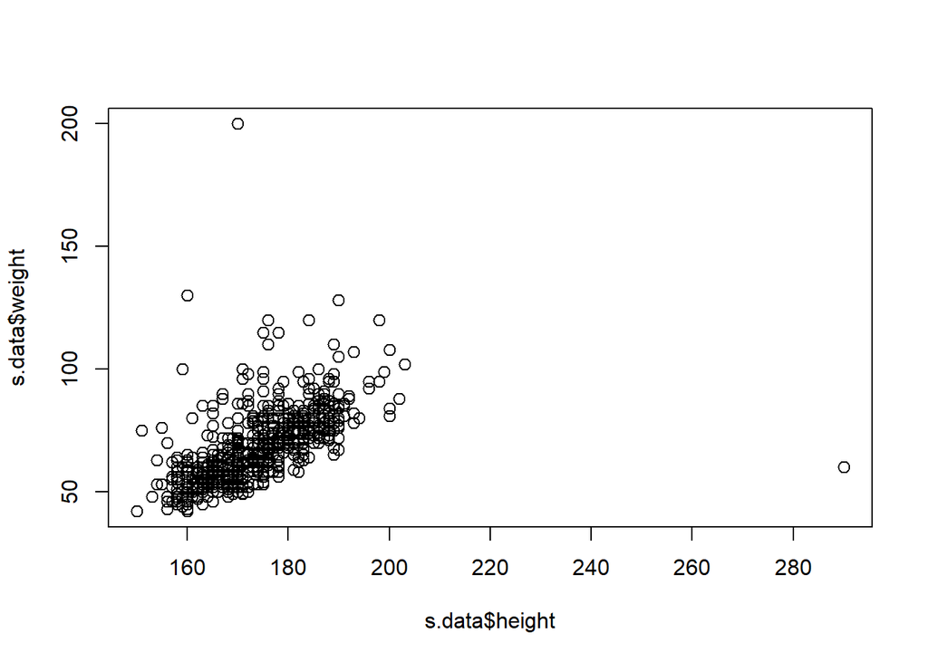

```r
plot(s.data$height, s.data$weight, cex = 1.2)           # zwei Ausreißer fallen auf
```

Da offensichtlich zwei Datenpunkte auffällig sind, betrachten wir diese etwas näher. Hierfür nutzen wir `subset()`, mit dem eine Teilmenge von Beobachtungen ausgewählt werden kann.

```r
subset(s.data, s.data$height > 240 | s.data$weight > 150, )     # logisches ODER "|"
```

|  | fem | age | height | weight | shoe | sport | veg_fruits | income | food | organic |
| --- | --- | --- | --- | --- | --- | --- | --- | --- | --- | --- |
| 329 | 1 | 15 | 290 | 60 | 36 | 20 | 0 | 50 | 10 | never |
| 330 | 1 | 88 | 170 | 200 | 45 | 5 | 0 | 3000 | 2999 | never |

Wir wollen beide Beobachtungen (und dazu noch einen Ausreißer bei `income`) aus dem Datensatz entfernen und arbeiten dann mit dem bereinigten Datensatz `data_oA` weiter.

```r
data_oA <- subset(s.data, s.data$height < 240 & s.data$weight < 150 & s.data$income < 10000, )
```

Wir erstellen nun wieder das Streudiagramm für Größe und Gewicht. Wir tragen Hilfslinien für das mittlere Gewicht und die mittlere Größe ein.

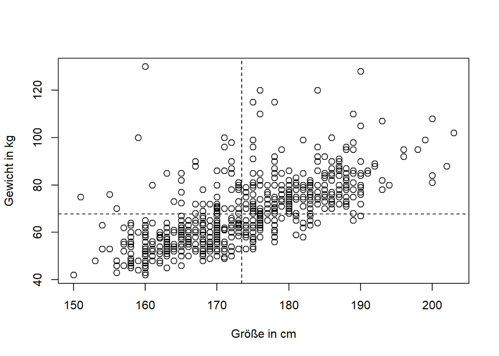

```r
plot(data_oA$height, data_oA$weight, cex = 1.2,
xlab = "Größe in cm", ylab = "Gewicht in kg")
abline(h = mean(data_oA$weight), lty = 2) # horizontale Hilfslinie
abline(v = mean(data_oA$height), lty = 2) # vertikale Hilfslinie
```

Wir erkennen, dass relativ viele Datenpunkte in den Sektoren Nordost und Südwest liegen. Die Datenpunkte formen eine Punktwolke, die näherungsweise **linear** ist und einen positiven Anstieg hat.

#### Kovarianz

Die Kovarianz ist das mittlere Produkt der Abweichungen der Beobachtungen von ihrem eigenen arithmetischen Mittel. Sie ist ein Maß für den **“Datengleichklang”** der Beobachtungen.

Die Kovarianz $\widehat{cov}_{XY}$ ist definiert als:

$\widehat{cov}_{XY}=\frac{1}{n-1}\sum_{i=1}^n(x_{i}-\bar{x})(y_{i}-\bar{y})$

Wir berechnen die Kovarianz mit `cov()`.

```r
cov(data_oA$height, data_oA$weight)
```

```
## [1] 93.576
```

Das **Vorzeichen der Kovarianz** liefert eine wichtige Information. Ist $\widehat{cov}_{XY} > 0$, gehen relativ große Beobachtungen von $X$ einher mit relativ großen Beobachtungen von $Y$ und umgekehrt. Gilt dagegen $\widehat{cov}_{XY} < 0$, gehen relativ große Beobachtungen von $X$ einher mit relativ kleinen Beobachtungen von $Y$ und umgekehrt. Hier ist die Kovarianz positiv, was nach dem Streudiagramm zu erwarten war. Ist $\widehat{cov}_{XY} = 0$, gibt es keinen linearen Zusammenhang zwischen $X$ und $Y$.

Ein Problem bei der Kovarianz ist, dass sie als Einheit das Produkt der Einheiten beider Variablen hat. Zudem ist die Kovarianz nicht beschränkt auf ein Intervall, was ihre Interpretation erschwert. Um ein Maß für die Stärke und Richtung eines linearen Zusammenhangs zu haben, wäre ein dimensionsloses Maß im Intervall [-1,1] besser.

#### Berechnung und Interpretation

Der Pearson-Korrelationskoeffizient $r_{XY}$ ist definiert als:

$r_{XY}=\frac{\widehat{cov}_{XY}}{\widehat{\sigma}_{X}\widehat{\sigma}_{Y}}\in[-1,1]$

Dabei ist $\widehat{cov}_{XY}$ die Kovarianz von $X$ und $Y$, $\widehat{\sigma}_{X}$ die Standardabweichung von $X$ und $\widehat{\sigma}_{Y}$ die Standardabweichung von $Y$.

Folgende Eigenschaften von $r_{XY}$ sind besonders wichtig:

- $r_{XY}$ misst die Stärke (durch den Betrag) und die Richtung (durch das Vorzeichen) des linearen Zusammenhangs zwischen $X$ und $Y$,
- $r_{XY}$ liegt im Intervall [-1,1],
- $r_{XY}$ ist dimensionslos.

Wir berechnen $r_{XY}$ für unser Beispiel mit den Befehlen für Kovarianz und Standardabweichung und mit `cor()`:

```r
rXY <- cov(data_oA$height, data_oA$weight)/(sd(data_oA$height)*sd(data_oA$weight)); rXY
```

```
## [1] 0.68775
```

```r
cor(data_oA$height, data_oA$weight, method = "pearson")
```

```
## [1] 0.68775
```

Der Pearson-Korrelationskoeffizient ist $r_{XY} = 0.69$, d.h., es gibt einen relativ starken, positiven, linearen Zusammenhang zwischen Größe und Gewicht. Bei der Interpretation von $r_{XY}$ ist die **Richtung** (Vorzeichen) und die **Stärke** (Absolutwert = Effektgröße) des linearen Zusammenhangs immer anzugeben.

Damit $r_{XY}$ berechnet und sinnvoll interpretiert werden kann, müssen bestimmte **Bedingungen** erfüllt sein:

1. Es müssen quantitative Daten (Zahlen mit Einheiten) vorliegen.
2. Es muss ein linearer Zusammenhang vorliegen (zu prüfen über ein Streudiagramm).
3. Ausreißer können $r_{XY}$ stark beeinflussen. Ggf. sind Ausreißer zu entfernen oder es sind zwei Berechnungen durchzuführen (mit und ohne Ausreißer).

Betrachten wir ein weiteres Beispiel aus dem oben eingelesenen Datensatz:

```r
names(data_oA)
```

```
##  [1] "fem"        "age"        "height"     "weight"     "shoe"
##  [6] "sport"      "veg_fruits" "income"     "food"       "organic"
```

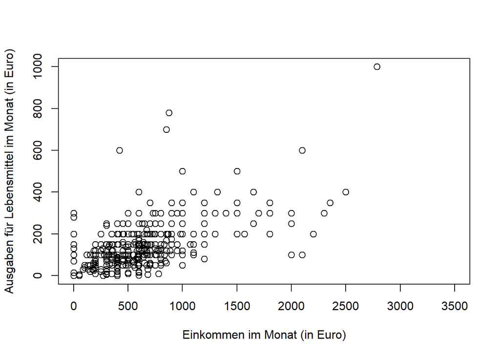

```r
plot(data_oA$income, data_oA$food, cex = 1.2,
     xlab = "Einkommen im Monat (in Euro)",
     ylab = "Ausgaben für Lebensmittel im Monat (in Euro)")
```

```r
summary(data_oA$income)
```

```
##    Min. 1st Qu.  Median    Mean 3rd Qu.    Max.
##       0     400     600     614     750    3500
```

```r
summary(data_oA$food)                                # Achtung: es gibt NAs bei food
```

```
##    Min. 1st Qu.  Median    Mean 3rd Qu.    Max.     NAs
##       0      90     120     147     200    1000     158
```

Die Berechnung von $r_{XY}$ verlangt paarweise vollständige Beobachtungen. Dies lässt sich als Argument in `cor()` einfügen.

```r
cor(data_oA$income, data_oA$food, method = "pearson") # method = "pearson" ist der Standard
```

```
## [1] NA
```

```r
cor(data_oA$income, data_oA$food, use = "pairwise.complete.obs") # wichtig ist "use = "
```

```
## [1] 0.5091
```

Es gibt einen mittelstarken, positiven, linearen Zusammenhang zwischen Einkommen und Ausgaben für Lebensmittel. Achtung: Wir treffen hier noch **keine Aussage über Kausalität**. Dazu später mehr im Kapitel “Regression”.

### Spearman-Korrelationskoeffizient

Spearman’s $\rho$ (“roh”) wird für qualitative Daten, die ordinal skaliert sind, berechnet. Typische Anwendungsfälle sind Noten, Punkte oder Zustimmung zu einer Aussage mit Antworten wie {“absolute Zustimmung”, “mir egal”, “bin dagegen”}.

#### Berechnung und Interpretation

Wir betrachten hier ein Beispiel, in dem Noten für Mathematik und Statistik vorliegen (Beispiel 4.4 im Lehrbuch, S. 75). Die ordinal skalierten Merkmale liegen also bereits als Zahl vor. Wenn dies nicht der Fall ist, müssen die Ausprägungen umkodiert werden (vgl. Exkurs unten).

Wir lesen zunächst die Noten für Mathematik (`NoteM`) und Statistik (`NoteS`) ein.

```r
NoteM <- c(1.3, 4, 5, 2.3, 1, 1.7, 1, 3, 3.7, 2.7)
NoteS <- c(2, 3.7, 3.3, 2.7, 1.3, 1, 1.7, 2.3, 3, 3)
```

Bevor wir die Ränge der Ausprägungen bestimmen, ist auch hier ein Streudiagramm sinnvoll.

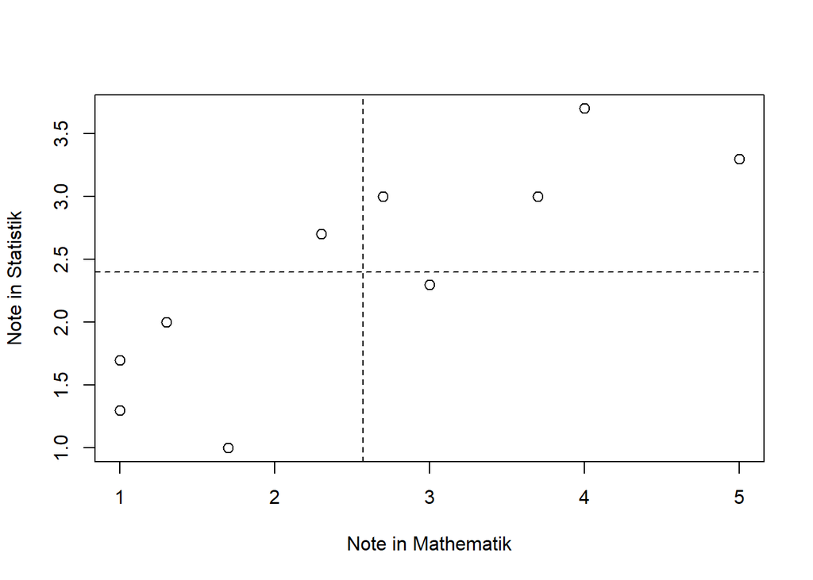

```r
plot(NoteM, NoteS,  xlab = "Note in Mathematik", ylab = "Note in Statistik", cex = 1.2)
abline(h = mean(NoteS), lty = 2) # horizontale Hilfslinie
abline(v = mean(NoteM), lty = 2) # vertikale Hilfslinie
```

Offensichtlich gibt es einen relativ starken, positiven, linearen Zusammenhang zwischen den Noten für Mathematik und Statistik. Auf Grund der Ordinalskala können wir aber die Abstände zwischen den Ausprägungen nicht so interpretieren wie bei quantitativen Daten. Zum Beispiel ist der Abstand von einer 1 zu einer 2 nicht gleichwertig wie der Abstand von einer 2 zu einer 3. Bei ordinal skalierten Merkmalen müssen daher **Ränge** gebildet werden. Diese Ränge werden dann als quantitative Maßzahl interpretiert und zur Berechnung der Korrelation herangezogen.

Der Spearman-Korrelationskoeffizient $\rho_{XY}$ ist gleich dem Pearson-Korrelationskoeffizienten der Ränge ($rg$) und definiert als:

$\rho_{XY}=\frac{\widehat{cov}_{rg(X)rg(Y)}}{\widehat{\sigma}_{rg(X)}\widehat{\sigma}_{rg(Y)}}\in[-1,1]$

Dabei ist $\widehat{cov}_{rg(X)rg(Y)}$ die Kovarianz der Ränge von $X$ und $Y$, $\widehat{\sigma}_{rg(X)}$ die Standardabweichung des Ranges von $X$ und $\widehat{\sigma}_{rg(Y)}$ die Standardabweichung des Ranges von $Y$.

Wir bestimmen zunächst die Ränge der Noten für Mathematik und Statistik mit `rank()`.

```r
NoteM; rank(NoteM)
```

```
##  [1] 1.3 4.0 5.0 2.3 1.0 1.7 1.0 3.0 3.7 2.7
```

```
##  [1]  3.0  9.0 10.0  5.0  1.5  4.0  1.5  7.0  8.0  6.0
```

```r
NoteS; rank(NoteS)
```

```
##  [1] 2.0 3.7 3.3 2.7 1.3 1.0 1.7 2.3 3.0 3.0
```

```
##  [1]  4.0 10.0  9.0  6.0  2.0  1.0  3.0  5.0  7.5  7.5
```

Zur Berechnung: Die Ränge werden aufsteigend (von klein zu groß) vergeben. Bei gleichen Ausprägungen wird das arithmetische Mittel der zu vergebenen Ränge zugewiesen. Zum Beispiel bei `NoteM`: Die 1.0 bei Mathematik gibt es zwei Mal, daher wird das arithmetische Mittel der Ränge 1 und 2, hier (1+2)/2 = 1.5, vergeben. Die 1.3 erhält dann den Rang 3.

Die Ränge können als quantitatives Merkmal interpretiert werden. Wir berechnen daher von diesen Rängen die Kovarianz und die Standardabweichungen. Wir berechnen dann $\rho_{XY}$ mit

```r
cov(rank(NoteM), rank(NoteS))/(sd(rank(NoteM))*sd(rank(NoteS)))
```

```
## [1] 0.86585
```

Natürlich geht es auch einfacher mit `cor()` und `method = "spearman"`.

```r
cor(NoteM, NoteS, method = "spearman")
```

```
## [1] 0.86585
```

Der Spearman-Korrelationskoeffizient liegt bei $\rho_{XY} = 0.87$, d.h., es gibt einen starken, positiven, linearen Zusammenhang zwischen den Rängen der Noten für Mathematik und Statistik.

#### Exkurs: Umkodieren von Kategorie zu Zahl

Beispiel: Es liegen Ausprägungen für Fragen der Art “Wie sinnvoll finden Sie diese Veranstaltung?” mit {total sinnvoll, mittel, Blödsinn} vor. In diesem Fall ist ein Umkodieren von Kategorie zu Zahl nötig. Dies ist hier möglich, da sich die Merkmalsausprägungen ordnen lassen.

Zunächst erzeugen wir uns einen Datensatz. Wir definieren die Merkmale `Bewertung` und `Alter` und erstellen mit `data.frame()` eine Datentabelle.

```r
Tab <- data.frame(Bewertung = c("total sinnvoll", "mittel", "total sinnvoll", "Blödsinn",
                                "Blödsinn", "total sinnvoll", "mittel", "total sinnvoll"),
                  Alter = c(19, 27, 18, 22, 19, 26, 30, 27))
Tab[1:5, ]
```

|  | Bewertung | Alter |
| --- | --- | --- |
| 1 | total sinnvoll | 19 |
| 2 | mittel | 27 |
| 3 | total sinnvoll | 18 |
| 4 | Blödsinn | 22 |
| 5 | Blödsinn | 19 |

Das Umkodieren des Merkmals `Bewertung` in geordnete und zahlenmäßige Ausprägungen ist dann mit `ifelse()` möglich. Wir ergänzen eine neue Spalte in `Tab`.

```r
Bewertung_Zahl <- ifelse(Tab[,1] == "total sinnvoll", 1, ifelse(Tab[,1] == "mittel", 2, 3))
cbind(Tab, Bewertung_Zahl) [1:5, ] # cbind() bindet Spalten (columns) aneinander
```

|  | Bewertung | Alter | Bewertung_Zahl |
| --- | --- | --- | --- |
| 1 | total sinnvoll | 19 | 1 |
| 2 | mittel | 27 | 2 |
| 3 | total sinnvoll | 18 | 1 |
| 4 | Blödsinn | 22 | 3 |
| 5 | Blödsinn | 19 | 3 |

### Korrigierter Kontingenzkoeffizient

Ziel ist hier zu untersuchen, wie stark zwei nominal skalierte Merkmale voneinander abhängig sind.

#### Kontingenztabelle

Eine Kontingenztabelle stellt die gemeinsame Verteilung von zwei nominal skalierten Merkmalen dar.

Betrachten wir hierzu ein Beispiel:

```r
setwd("C:/Users/sturm/Desktop/dataR")   # setze das Arbeitsverzeichnis
data <- read.csv("Bsp._2.1.csv")
# data <- read.csv("https://raw.githubusercontent.com/bodosturm/dataR/main/Bsp._2.1.csv")
attach(data)
addmargins(table(Journal, Gender))
```

```
##                     Gender
## Journal              Female Male Sum
##   Cosmopolitan           45    5  50
##   Economist               5   10  15
##   Sports Illustrated     10   25  35
##   Sum                    60   40 100
```

Die Idee ist: Wir wollen die Stärke der Abhängigkeit zwischen beiden Merkmalen im Intervall $[0,1]$ messen. Hierzu ermitteln wir die bedingten relativen Häufigkeiten. Hier im Beispiel: die relativen Häufigkeiten von `Journal` für Männer und für Frauen.

```r
prop.table(table(Journal, Gender), 2) # 2 = Spalte ist Bedingung
```

```
##                     Gender
## Journal                Female     Male
##   Cosmopolitan       0.750000 0.125000
##   Economist          0.083333 0.250000
##   Sports Illustrated 0.166667 0.625000
```

Offensichtlich unterscheidet sich die Verteilung von `Journal` für Männer deutlich von der Verteilung von `Journal` für Frauen. Der Modus von relH(Journal|Female) ist Cosmopolitan mit 75%. Der Modus von relH(Journal|Male) ist Sports Illustrated mit 62.5%. Wir können daraus schließen, dass die Merkmale `Journal` und `Gender` nicht unabhängig voneinander sind. Mit anderen Worten: Es besteht eine Abhängigkeit zwischen `Journal` und `Gender`. Wir wollen nun diese Abhängigkeit quantifizieren.

#### Berechnung und Interpretation

Ausgangspunkt der Überlegungen ist die **Definition von statistischer Unabhängigkeit**. Wir betrachten zwei Merkmale $X$ und $Y$. Die Randverteilung von $X$, mit $i = 1,..., k$ Zeilen in der Kontingenztabelle, ist $h_{i\bullet}$. Die Randverteilung von $Y$, mit $j = 1,..., l$ Spalten in der Kontingenztabelle, ist $h_{\bullet j}$. Die bedingte Verteilung von $X$ für eine Ausprägung von $Y$ ist $h_{i|j} = \frac{h_{ij}}{h_{\bullet j}}$.

Die Merkmale $X$ und $Y$ sind unabhängig, wenn gilt:

$h_{i|j} = h_{i \bullet}$

Zwei Merkmale $X$ und $Y$ sind also unabhängig voneinander, wenn die bedingten relativen Häufigkeiten von $X$ für unterschiedliche Ausprägungen von $Y$ konstant und gleich der Randverteilung von $X$ sind.

Aus der Definition von Unabhängigkeit lassen sich die erwarteten relativen Häufigkeiten bei Unabhängigkeit herleiten mit:

$h_{ij} = h_{i \bullet}h_{\bullet j}$

und die erwarteten absoluten Häufigkeiten bei Unabhängigkeit mit:

$E_{ij} = n h_{i \bullet}h_{\bullet j} = \frac{n_{i \bullet}n_{\bullet j}}{n} = \frac{n_{Zeile_i} n_{Spalte_j}}{n}$

Um nun das Ausmaß der Abhängigkeit zu quantifizieren, betrachten wir die Differenz $n_{ij} - E_{ij}$, quadrieren diese Abweichung und setzen den Wert $(n_{ij} - E_{ij})^{2}$ in Relation zu $E_{ij}$. Die resultierenden Werte werden über alle $k$ Zeilen und $l$ Spalten aufsummiert. Wir erhalten die **quadratische Kontingenz QK**:

$QK = \sum_{i=1}^k \sum_{j=1}^l \frac{(n_{ij} - E_{ij})^{2}}{E_{ij}}$

Je größer $QK$, umso größer ist die Abhängigkeit zwischen $X$ und $Y$. Im Fall statistischer Unabhängigkeit ist $QK = 0$. Für perfekte Abhängigkeit ist $QK \rightarrow \infty$.

Die erwarteten absoluten Werte bei Unabhängigkeit ergeben sich mit `chisq.test()`.

```r
chi <- chisq.test(table(Journal, Gender)) # Definiere Objekt chi
chi$expected            # erwartete abs. Häufigkeiten bei Unabhängigkeit
```

```
##                     Gender
## Journal              Female Male
##   Cosmopolitan           30   20
##   Economist               9    6
##   Sports Illustrated     21   14
```

Man beachte: In der Tabelle `chi$expected` sind die bedingten relativen Häufigkeiten identisch, d.h. relH(Journal|Female) = relH(Journal|Male).

Die Berechnung von $QK$ erfolgt folgendermaßen:

```r
QK <- sum((table(Journal, Gender) - chi$expected)^2/chi$expected); QK
```

```
## [1] 37.599
```

Schließlich wollen wir ein im Intervall $[0,1]$ normiertes Maß für die **Stärke der Abhängigkeit** nutzen. Dieses Maß ist der korrigierte Kontingenzkoeffizient ($KK^{*}$), der sich folgendermaßen berechnet:

$KK^{*} = \sqrt {\frac{QK \cdot m}{(QK+n)(m-1)}}\in[0,1]$

Hier ist $QK$ die quadratische Kontingenz, $n$ ist die Zahl der Beobachtungen in der Kontingenztabelle und $m$ ist $min(k,l)$, also die kleinere Zahl von Spalten- und Zeilenzahl in der Kontingenztabelle. Wie man sieht: Wenn $QK\rightarrow \infty$: $KK^*=1$ und $QK\rightarrow 0$: $KK^*=0$.

```r
n <- 100; m <- 2
KK_stern <- sqrt( QK*m /((QK + n)*(m - 1))  ); round(KK_stern, 3)
```

```
## [1] 0.739
```

Der Wert $KK^{*} = 0.74$ zeigt, dass die beiden Merkmale `Journal` und `Gender` relativ stark voneinander abhängig sind. Es ist aber basierend auf $KK^{*}$ keine Aussage zur Richtung des Zusammenhangs bzw. zur Kausalität möglich.

$KK^{*}\in[0,1]$ ist ein deskriptives Maß zur Messung der Stärke der Abhängigkeit (Effektgröße) zwischen zwei nominal skalierten Merkmalen in einer Stichprobe. Die Frage, ob eine solche Abhängigkeit zufällig bei der Stichprobenziehung zustandegekommen ist oder es diese Abhängigkeit in der Grundgesamtheit tatsächlich gibt (<=> statistische Signifikanz), kann erst durch einen Test auf Unabhängigkeit (vgl. unten) beantwortet werden.

#### Exkurs: Liniendiagramm

Der folgende Code zeigt ein einfaches Liniendiagramm. Mit `plot()` kann eine Kombination von Variablen dargestellt werden. Mit `lines()` können dann beliebig viele Kombinationen zusätzlich dargestellt werden.

```r
x <- 1:200; x[1:10]            # Definition x
```

```
##  [1]  1  2  3  4  5  6  7  8  9 10
```

```r
y <- 20*x^2 - 0.1*x^3; y[1:10] # Definition y
```

```
##  [1]   19.9   79.2  177.3  313.6  487.5  698.4  945.7 1228.8 1547.1 1900.0
```

```r
y2 <- 2*x^2; y2[1:10]
```

```
##  [1]   2   8  18  32  50  72  98 128 162 200
```

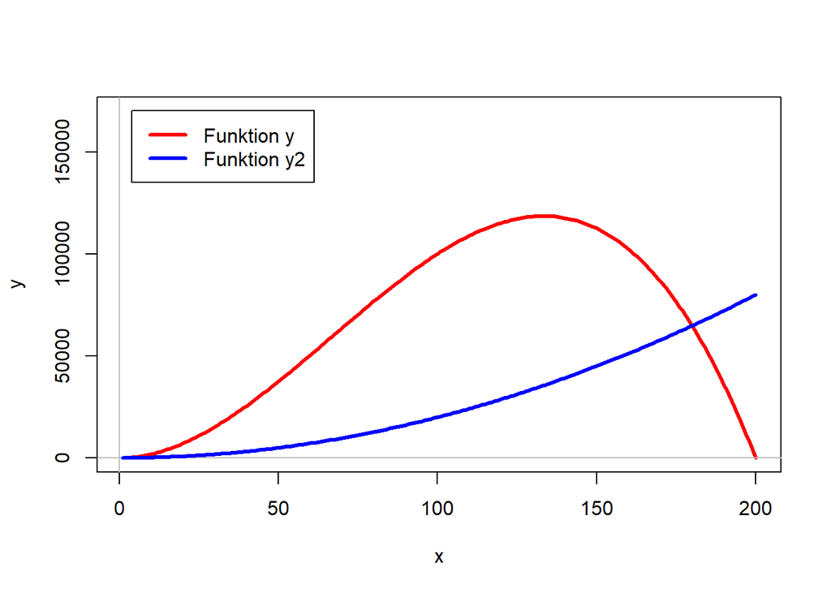

```r
# Liniendiagramm, type = "l" mit l wie lachen:)
plot(x, y, type = "l", ylim = c(0, 170000), col = "red", lwd = 3)
abline(h = 0, col = "grey")    # Hilfslinie
abline(v = 0, col = "grey")    # Hilfslinie
lines(x, y2, lwd = 3, col = "blue")
legend(4, 170000, col = c("red","blue"),
       lwd = c(3,3), c("Funktion y", "Funktion y2"))
```

Mit `legend()` wird die Legende über den Plot gelegt. Für die Position der Legende sind passende x-y-Koordinaten zu wählen.

Eine alternative Darstellung einer Funktion ist mit `curve()` möglich. Der Befehl `curve()` verlangt dabei die Definition einer Funktion mit dem Argument `x`. Mit `add = TRUE` können mehrere Funktionen dargestellt werden. Anbei ein Beispiel:

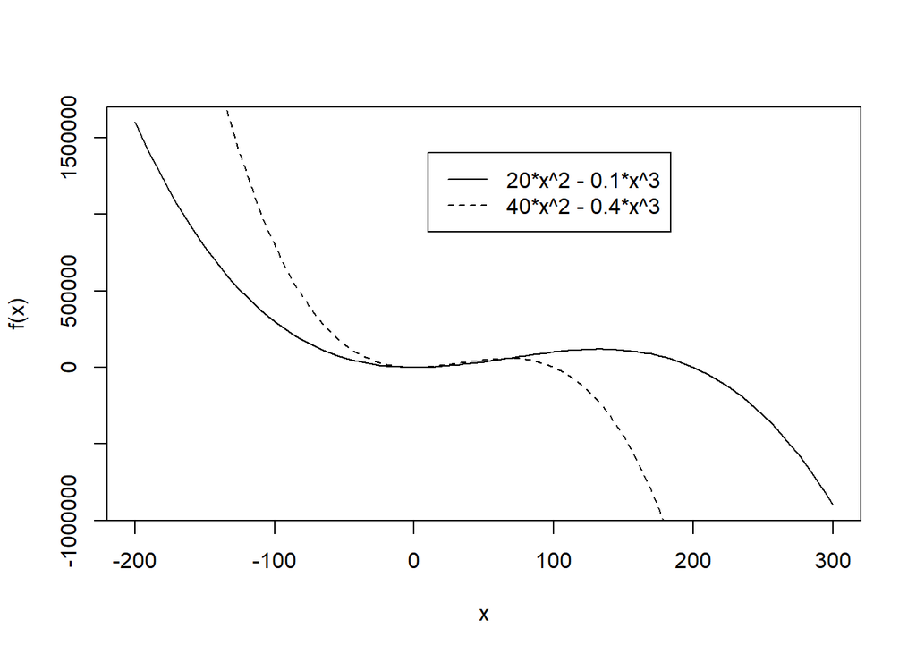

```r
curve(20*x^2 - 0.1*x^3, xlim = c(-200, 300), ylab = "f(x)")
curve(40*x^2 - 0.4*x^3, xlim = c(-200, 300), lty = 2, add = TRUE)
legend(10, 1400000, lty = c(1,2), c("20*x^2 - 0.1*x^3", "40*x^2 - 0.4*x^3"))
```

Ein weiteres Beispiel, welches die Entwicklung des Ölpreises zeigt.

```r
setwd("C:/Users/sturm/Desktop/dataR")   # setze das Arbeitsverzeichnis
data <- read.csv("oilprices.csv")
# data <- read.csv("https://raw.githubusercontent.com/bodosturm/dataR/main/oilprices.csv")
data[1:2, ]; attach(data)
```

|  | Year | currentUSD | USD2020 |
| --- | --- | --- | --- |
| 1 | 1960 | 1.63 | 8.51 |
| 2 | 1961 | 1.57 | 8.05 |

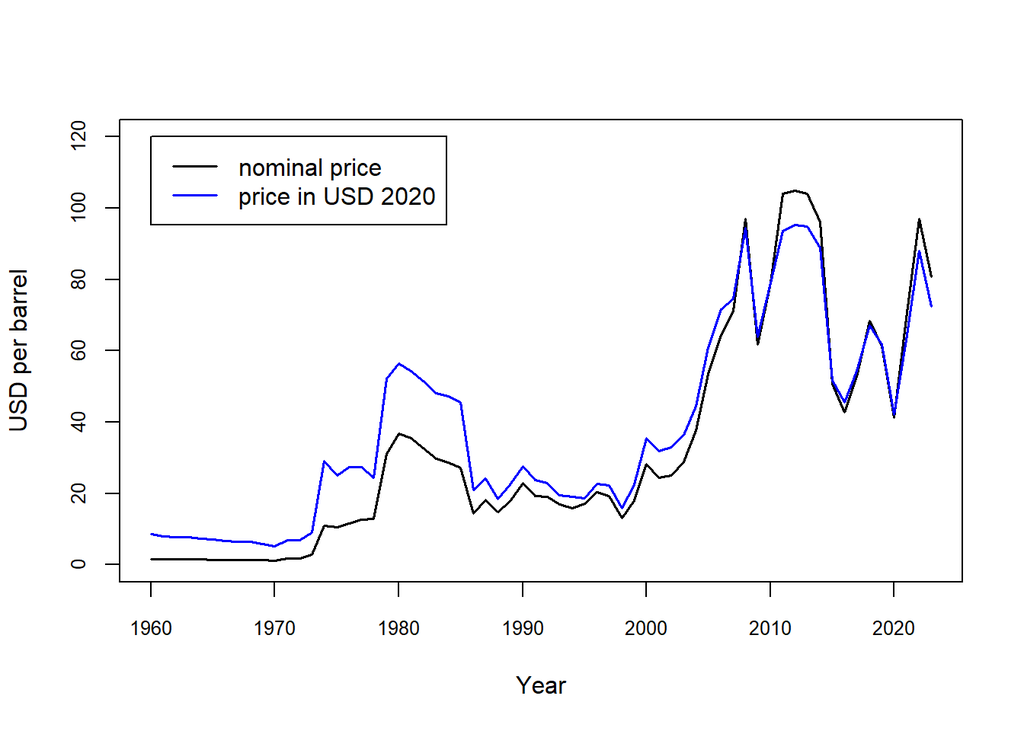

```r
plot(Year, currentUSD, xlab = "Year", ylab = "USD per barrel", type = "l", cex.axis = 0.8,
     lwd = 1.5, ylim = c(0, 120))
lines(Year, USD2020, col = "blue", lwd = 1.5)
legend(1960, 120, lty = c(1,1), c("nominal price", "price in USD 2020"),
       col = c("black", "blue"), lwd = c(1.5, 1.5))
```

Man kann gut die Preisspitzen in den Ölkrisen der 1970er Jahre erkennen. Ab 2000 ist der Ölpreis wieder deutlich angestiegen, dann aber ab 2015 wieder gesunken. Zugleich kann man erkennen, dass der Ölpreis inflationsbereinigt (also in Gütereinheiten gemessen) bereits relativ hoch in der Vergangenheit war.

## Regression (nur W501 und W873)

Wir wollen nun die Abhängigkeit einer Variablen $Y$ von einer Variablen $X$ beschreiben. Dabei konzentrieren wir uns zunächst auf eine **lineare Abhängigkeit** (lineare Einfachregression, auch “lineares Modell”). Später erweitern wir die Betrachtung auf nicht-lineare Zusammenhänge, die wir durch eine geeignete Transformation in einen linearen Zusammenhang überführen (log-Transformation).

### Lineare Einfachregression

#### Theorie

Wir nehmen an, dass es einen linearen Zusammenhang zwischen $X$ und $Y$ gibt. Wir bezeichnen $X$ als unabhängige bzw. erklärende und $Y$ als abhängige bzw. zu erklärende Variable. Ziel ist es, eine Regressionsgerade so zu schätzen, dass diese den linearen Zusammenhang zwischen $X$ und $Y$ bestmöglich beschreibt.

Die Regressionsgerade sei bezeichnet mit

$\widehat y = \beta_0 + \beta_1x$

Der Parameter $\beta_0$ ist der Achsenabschnitt, d.h. $\widehat {y}(x = 0) = \beta_0$, und $\beta_1$ ist der Anstiegsparameter, d.h. $d\widehat {y}/dx = \beta_1$.

Wir unterstellen keinen perfekten linearen Zusammenhang zwischen $X$ und $Y$, sondern es gibt “Abweichungen” $u$ (auch “Fehlerterme” oder “Residuen” genannt) vom linearen Zusammenhang in der $y$-Dimension, so dass gilt

$y = \beta_0 + \beta_1x + u$

Damit gelten folgende Definitionen:

$\widehat y$ = Werte auf der Regressionsgeraden bzw. Prognose der Regressionsgeraden (“predicted”)

$y$ = beobachtete Werte für $Y$ (“observed”)

$x$ = beobachtete Werte für $X$

$u = y - \widehat y$ = Fehlerterm = Beobachtung für $Y$ $-$ Prognose für $Y$ = observed $-$ predicted

Die Methode zur Bestimmung der Regressionsgeraden ist relativ einfach. Man minimiert die Summe der quadrierten Fehlerterme. Aus dieser **Minimierung** ergibt sich eine algebraische Lösung für $\beta_0$ und $\beta_1$.

Mit anderen Worten, man bestimmt (für $i = 1, ..., n$ Beobachtungspaare)

$\sum u^{2}(\beta_0, \beta_1) \rightarrow min!$

mit

$\sum u^{2}(\beta_0, \beta_1) = \sum (y - \widehat y)^2 = \sum (y - \beta_0 - \beta_1x)^2$

Mit etwas Rechenaufwand (vgl. Lehrbuch) lässt sich zeigen, dass gilt

$\beta_0 = \bar{y} - \beta_1\bar{x}$

und

$\beta_1 = \frac{\widehat{cov}_{XY}}{\widehat{\sigma}_{X}^2}$

#### Beispiel I

Wir betrachten das folgende Beispiel mit den Variablen `totalcost` und `output`. Der Output wird in Mengeneinheiten (ME) angegeben, die Gesamtkosten in 1000 Euro.

```r
setwd("C:/Users/sturm/Desktop/dataR")   # setze das Arbeitsverzeichnis
data <- read.csv("Bsp._5.2.csv")
# data <- read.csv("https://raw.githubusercontent.com/bodosturm/dataR/main/Bsp._5.2.csv")
attach(data); data[1:2, ]
```

|  | output | totalcost |
| --- | --- | --- |
| 1 | 20 | 25.1 |
| 2 | 21 | 25.2 |

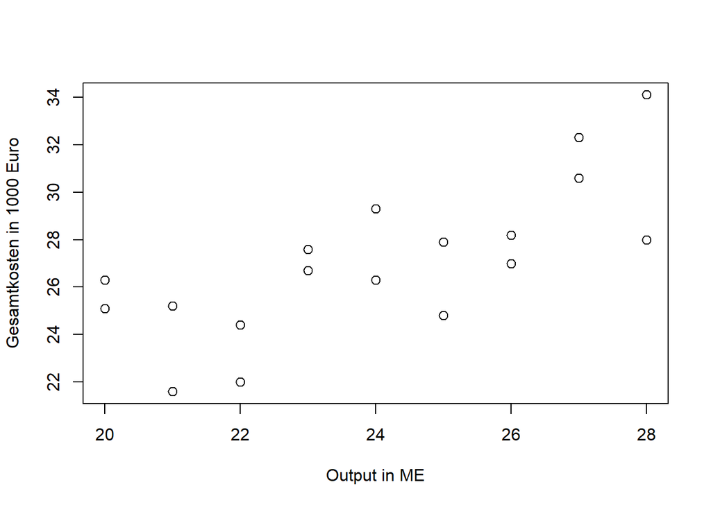

```r
plot(output, totalcost, cex = 1.2,
xlab = "Output in ME", ylab = "Gesamtkosten in 1000 Euro")
```

Wie wir sehen, gibt es einen relativ starken, positiven, **linearen Zusammenhang** zwischen `totalcost` und `output`. Wir können das Streudiagramm etwas erweitern und die Regressionsgerade einzeichnen. Die Berechnung der Regressionsgeraden erfolgt mit `lm(y ~ x)`, wobei `y` die abhängige bzw. zu erklärende Variable ist und `x` die unabhängige bzw. erklärende Variable. Wir können dann diese Regressionsgerade zu einem Streudiagramm hinzufügen mit `abline(lm(y ~ x))`.

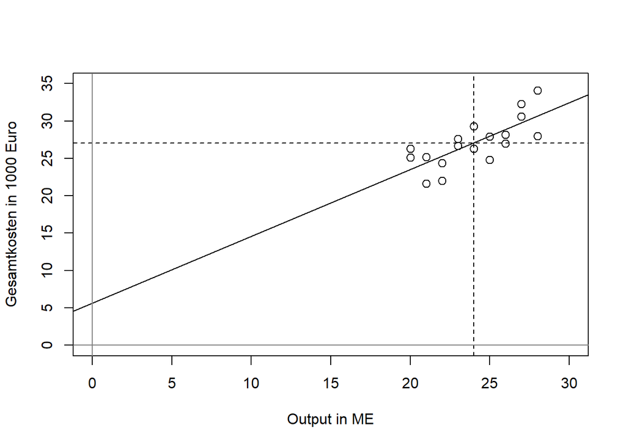

```r
plot(output, totalcost, cex = 1.2, xlab = "Output in ME",
     ylab = "Gesamtkosten in 1000 Euro", xlim = c(0,30), ylim = c(0,35))
abline(lm(totalcost ~ output))
abline(h = mean(totalcost), lty = 2)
abline(v = mean(output), lty = 2)
abline(h = 0, col = "grey50"); abline(v = 0, col = "grey50")
```

Die Regressionsgerade geht durch den Schwerpunkt (`mean(x)`, `mean(y)`) des Streudiagramms. Wir können zunächst die Werte für $\beta_0$ und $\beta_1$ graphisch ablesen:

$\beta_0$ = ca. 5000 Euro als fixe Kosten

$\beta_1$ = ca. 800 Euro/ME als variable Kosten bzw. Grenzkosten

Um die Regressionsgeraden zu berechnen, nutzen wir `lm(y ~ x)` mit `x` als unabhängige Variable $X$ und `y` als abhängige Variable $Y$ und definieren ein Objekt (hier `ols`). Dieses geben wir dann aus.

```r
ols <- lm(totalcost ~ output) # ols = ordinary least squares
ols
```

```
##
## Call:
## lm(formula = totalcost ~ output)
##
## Coefficients:
## (Intercept)       output
##       5.658        0.892
```

Man kann hier auch `summary(ols)` ausführen, wenn man Hypothesentests für Anstiegsparameter und Achsenabschnitt durchführen möchte (vgl. Lehrbuch, Kap. 12, oder das entsprechende Kapitel in diesem Skript).

Mit den Formeln für $\beta_0$ und $\beta_1$ erhalten wir analog

```r
b1 <- cov(output, totalcost)/var(output); b1
```

```
## [1] 0.8925
```

```r
b0 <- mean(totalcost) - b1*mean(output); b0
```

```
## [1] 5.6578
```

Zur Interpretation: Das Modell prognostiziert fixe Kosten der Produktion in Höhe von 5658 Euro und Grenzkosten der Produktion in Höhe von 892.5 Euro/ME.

Generell ist die **Prognose** eine wichtige Anwendung der Regression. Man kann z.B. einen beliebigen Wert für `output` nehmen und für diesen Wert mit Hilfe der Regressionsgleichung den Wert der abhängigen Variablen, hier `totalcost`, prognostizieren. Dabei ist natürlich der Kontext des Modells zu beachten.

```r
pred_35 <- b0 + b1*35 # Prognose für totalcost(output = 35)
pred_35
```

```
## [1] 36.895
```

Wichtige **Eigenschaften der Regressionsgeraden** sind:

- Die Regressionsgerade geht durch den Schwerpunkt des Streudiagramms, also den Punkt $(\bar{x}, \bar{y})$.
- Die Summe der Fehlerterme ist Null, d.h. $\sum u = 0$. Damit ist auch das arithmetische Mittel der Fehler Null ($\bar{u}=0$).
- Die Varianz der abhängigen Variablen, $\widehat{\sigma}_{Y}^2$, kann in zwei Teile zerlegt werden mit: $\widehat{\sigma}_{Y}^2 = \widehat{\sigma}_{\widehat{Y}}^2 + \widehat{\sigma}_{U}^2$. Dabei ist $\widehat{\sigma}_{\widehat{Y}}^2$ die Varianz der Werte auf der Regressionsgeraden (der “fitted values”) und $\widehat{\sigma}_{U}^2$ die Varianz der Fehlerterme.

Das Modell der linearen Regression ist nur dann sinnvoll zu nutzen, wenn bestimmte **Annahmen** gültig sind (zu prüfen über entsprechende Bedingungen):

1. Es müssen quantitative Daten (Zahlen mit Einheiten) vorliegen.
2. Der Zusammenhang muss linear sein (zu prüfen über ein Streudiagramm). Ggf. müssen die Daten in Teilgruppen unterteilt oder transformiert werden.
3. Ausreißer können einen starken Effekt auf die Regressionsgerade haben und müssen ggf. eliminiert werden.
4. Die Fehlerterme sollten eine konstante Streuung aufweisen (“Homoskedastizität”). Bei Verletzung dieser Annahme liegt “Heteroskedastizität” vor. Dies ist durch ein Streudiagramm der Residuen $u$ und der vorhergesagten Werte für $Y$, $\widehat y$, zu prüfen. In diesem Streudiagramm sollten keinerlei Strukturen oder Muster enthalten sein.

Betrachten wir zunächst ein Beispiel zur Bedeutung von Ausreißern:

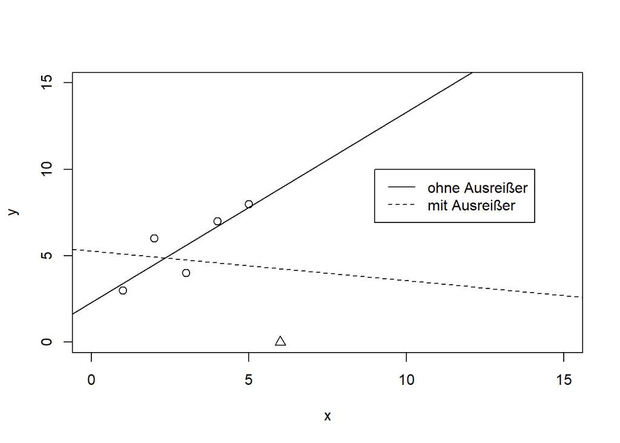

```r
x <- 1:5; y <- c(3, 6, 4, 7, 8)
x2 <- 1:6; y2 <- c(3, 6, 4, 7, 8, 0)
plot(x, y, cex = 1.2, xlim = c(0, 15), ylim = c(0, 15))
abline(lm(y ~ x))
points(x2[6], y2[6], cex = 1.2, pch = 2)
abline(lm(y2 ~ x2), lty = 2)
legend(9, 10, lty = c(1,2), c("ohne Ausreißer", "mit Ausreißer"))
```

Bereits ein Wert, hier (6, 0) weit weg vom allgemeinen Trend, kann die Lage der Regressionsgeraden stark beeinflussen. Für die ersten fünf Paare (`x`, `y`) ist der Anstieg positiv, mit dem 6. Paar (6, 0) wird der Anstieg jedoch negativ. Der Grund dafür, dass die Regressionsgerade so empfindlich auf Ausreißer in der $y$-Dimension reagiert, liegt in der Methode der Bestimmung der Regressionsgeraden. Minimiert wird die **Summe der quadrierten Fehlerterme**. Beobachtungen weit weg vom Trend (d.h., mit großem Fehlerterm und großer Abweichung zum arithmetischen Mittel von $x$) erhalten durch die Quadrierung ein besonders großes Gewicht bei der Bestimmung der Regressionsparameter und “verzerren” somit die Regression.

#### Residuen

Die Fehlerterme (auch “Residuen” genannt) sind der Teil des Regressionsmodells, der nicht erklärt wird. Die Residuen sind definiert als:

$u = y - \widehat y$ = Beobachtung $-$ Vorhersage = observed $-$ predicted

In den Residuen darf keinerlei systematische Information enthalten sein. Dies lässt sich am besten durch ein Streudiagramm mit der Vorhersage ($\widehat y$) auf der Abszisse und den Residuen ($u$) auf der Ordinate erkennen. Betrachten wir dieses Streudiagramm für das Beispiel I (Objekt `ols`) oben:

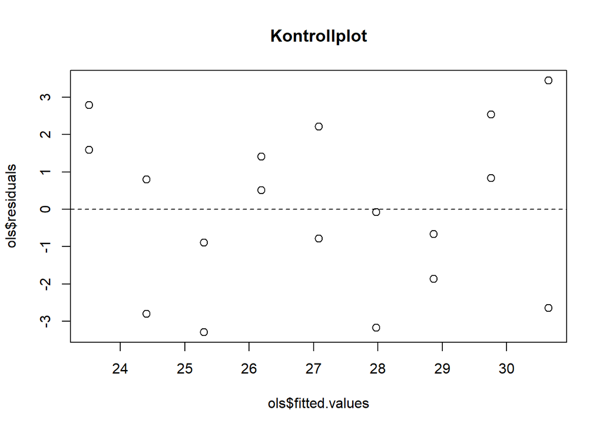

```r
plot(ols$fitted.values, ols$residuals, main = "Kontrollplot", cex = 1.2)
abline(h = 0, lty = 2)
```

In dem Streudiagramm für $\widehat y$ und $u$ (auch “Kontrollplot” genannt) ist keinerlei systematische Information zu erkennen. Man beachte, dass das arithmetische Mittel der Residuen Null ist.

#### Bestimmtheitsmaß

Um zu bewerten, wie gut ein Regressionsmodell den Zusammenhang zwischen $X$ und $Y$ abbildet, nutzt man die Information über die Streuung der Werte auf der Regressionsgeraden (“erklärte Varianz”, $\widehat{\sigma}_{\widehat Y}^2$) und die Streuung der Werte der abhängigen Variablen (“zu erklärende Varianz”, $\widehat{\sigma}_{Y}^2$).

Das Verhältnis der von der linearen Regression erklärten Varianz, $\widehat{\sigma}_{\widehat{Y}}^2$, zur Varianz der abhängigen Variablen, $\widehat{\sigma}_{Y}^2$, heißt “Bestimmtheitsmaß” und wird mit $R^2$ bezeichnet:

$R^2 = \frac{\widehat{\sigma}_{\widehat Y}^2}{\widehat{\sigma}_{Y}^2}= \frac{{\frac{1}{n-1}\sum(\widehat{y}-\bar{y})^2}}{\frac{1}{n-1}\sum(y-\bar{y})^2} =\frac{{\sum(\widehat{y}-\bar{y})^2}}{\sum(y-\bar{y})^2}$

$R^2$ misst also den Anteil der von der Regressionsgleichung erklärten Varianz an der Varianz der abhängigen Variablen (man beachte: $\bar{\widehat y}=\bar{y}$). Man kann zeigen, dass $0 \leq R^2 \leq 1$ gilt. Für die lineare Einfachregression gilt zudem, dass $R^2$ gleich dem Quadrat des Pearson-Korrelationskoeffizienten $r_{XY}$ ist, also $R^2=(r_{XY})^2$.

Wir berechnen $R^2$ für Beispiel I

```r
var(ols$fitted.values)
```

```
## [1] 5.6228
```

```r
var(ols$residuals)
```

```
## [1] 4.6085
```

```r
R2 <- var(ols$fitted.values)/var(totalcost); R2
```

```
## [1] 0.54957
```

```r
cor(output, totalcost)^2
```

```
## [1] 0.54957
```

Interpretation: Der Anteil der vom Modell erklärten Varianz an der Varianz der abhängigen Variablen beträgt 55%. Mit anderen Worten: Die unabhängige Variable `output` kann 55% der Streuung von `totalcost` erklären.

#### Beispiel II

Wir betrachten das folgende Beispiel mit den Variablen `P` und `Q`:

```r
setwd("C:/Users/sturm/Desktop/dataR")   # setze das Arbeitsverzeichnis
data <- read.csv("Elasticity.csv")
# data <- read.csv("https://raw.githubusercontent.com/bodosturm/dataR/main/Elasticity.csv")
data[1:2, ]; attach(data)
```

|  | P | Q |
| --- | --- | --- |
| 1 | 1 | 220.0 |
| 2 | 1 | 196.2 |

Die Menge $Q$ wird in Mengeneinheiten (ME) angegeben, der Preis $P$ in Euro. Ziel ist, eine Nachfragefunktion $Q(P)$ zu schätzen. Wir schätzen das lineare Modell $\widehat Q = \beta_0 + \beta_1P$.

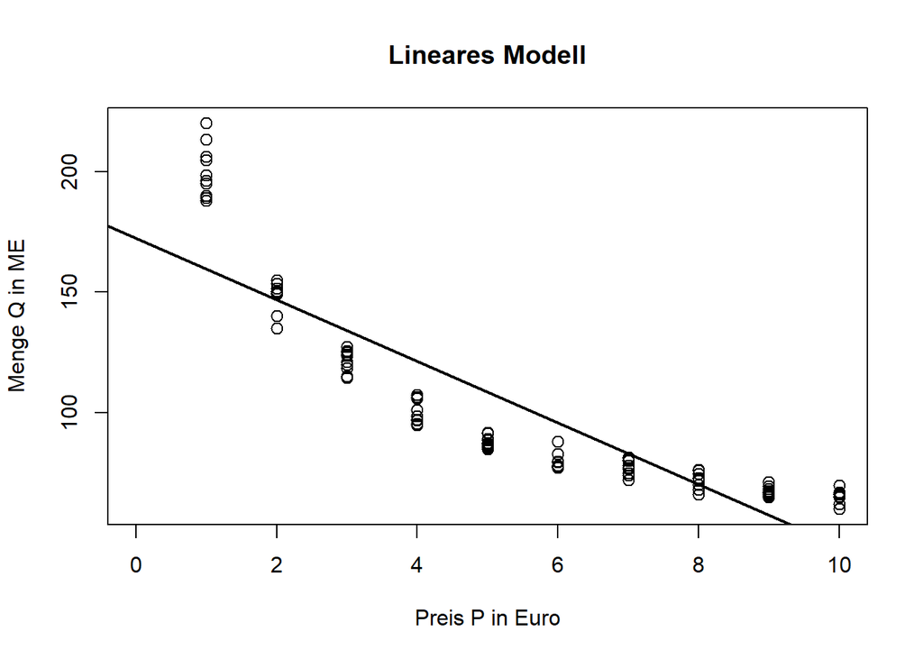

```r
plot(data$P, data$Q, cex = 1.2, xlab = "Preis P in Euro", ylab = "Menge Q in ME",
     main = "Lineares Modell", xlim = c(0, 10))
abline(lm(data$Q ~ data$P), lwd = 2)
```

```r
ols1 <- lm(data$Q ~ data$P); ols1
```

```
##
## Call:
## lm(formula = data$Q ~ data$P)
##
## Coefficients:
## (Intercept)       data$P
##       172.3        -12.7
```

Interpretation: Gemäß der Prognose des Modells geht im Mittel die Nachfrage um 12.75 ME zurück, wenn der Preis um 1 Euro steigt. Offensichtlich ist aber die Annahme eines linearen Zusammenhangs verletzt. Auch das Streudiagramm der Residuen und der vorhergesagten Werte zeigt, dass das lineare Modell die Abhängigkeit zwischen $P$ und $Q$ nicht richtig abbildet.

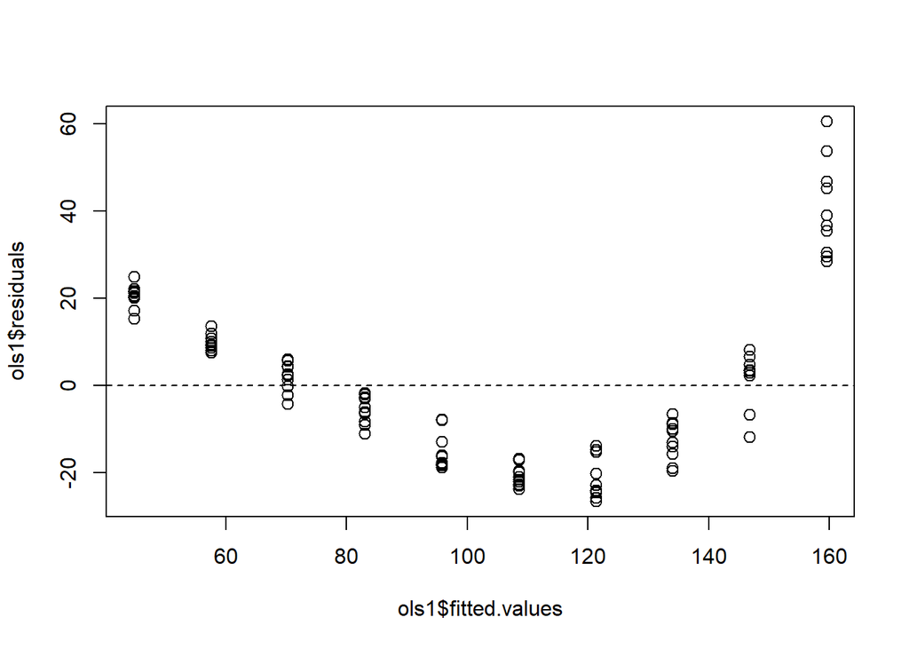

```r
plot(ols1$fitted.values, ols1$residuals, cex = 1.2)
abline(h = 0, lty = 2)
```

In diesem Plot ist eine deutliche **Struktur** erkennbar. Die Bedingung der Linearität ist verletzt und es liegt **Heteroskedastizität** vor: Die Streuung der Residuen ist nicht konstant. Wir müssen die Daten geeignet transformieren, um den Zusammenhang zu linearisieren.

### log-Transformation

In der Praxis liegen häufig **nicht-lineare Zusammenhänge** vor. Die lineare Einfachregression kann dann nicht angewendet werden. Durch eine geeignete Transformation lassen sich nicht-lineare Zusammenhänge aber häufig in lineare Zusammenhänge umwandeln. Das Konzept der linearen Einfachregression ist dann wieder anwendbar, allerdings ändert sich die Interpretation der Parameter des Regressionsmodells.

#### Exkurs: Logarithmus

Als Logarithmus $x$ einer Zahl $y$ bezeichnet man den Exponenten, mit dem eine vorher festgelegte Zahl, die Basis, potenziert werden muss, um die gegebene Zahl $y$ zu erhalten. Wird als Basis $e = 2.71828$, die Eulersche Zahl, gewählt, so erhält man den natürlichen Logarithmus.

$y = e^x$ => $x = log_e$ $y=ln$ $y$

In R wird der natürliche Log durch `log()` berechnet.

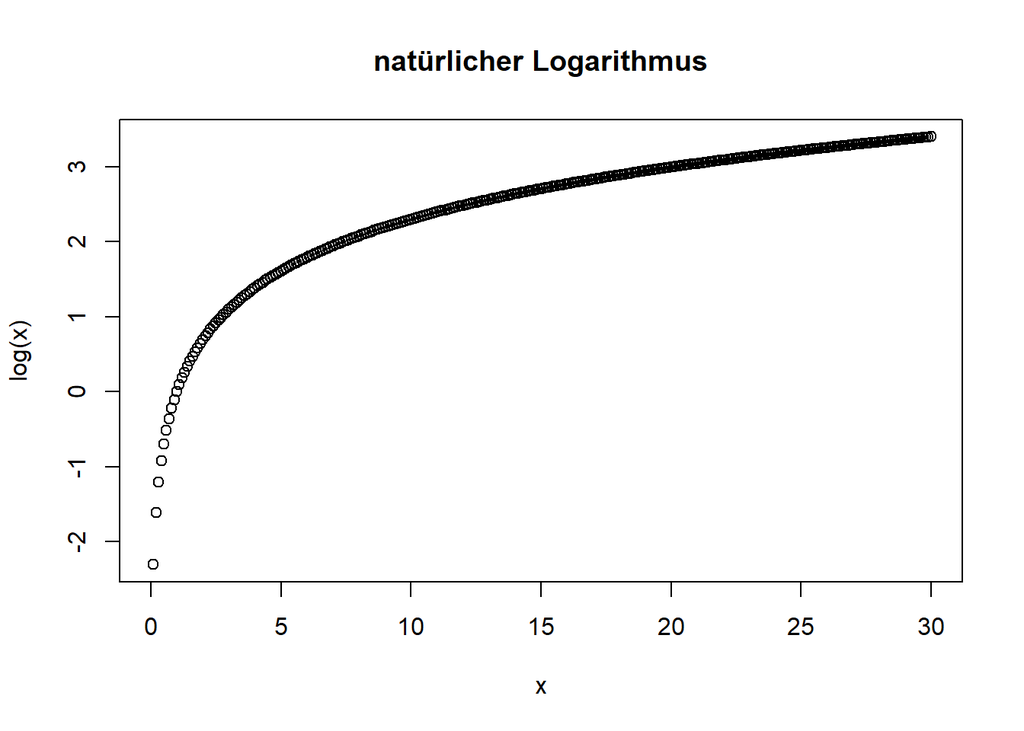

```r
x <- seq(0, 30, 0.1)
y <- log(x)
plot(x, y, ylab = "log(x)", main = "natürlicher Logarithmus")
```

Offensichtlich ist der natürliche Log eine nicht-lineare Funktion. Daher kann der natürliche Log auch verwendet werden, um bestimmte nicht-lineare Zusammenhänge zu linearisieren. Weiterhin hat der natürliche Log eine nützliche Eigenschaft: die logarithmierte Differenz einer Variablen misst näherungsweise die relative Änderung der ursprünglichen Variablen.

```r
1.05/1 - 1            # Wachstumsrate = 5%
```

```
## [1] 0.05
```

```r
log(1.05) - log(1)    # Differenz der Logs = ca. 5%
```

```
## [1] 0.04879
```

#### Theorie

Ausgehend von einem linearen Modell $\widehat {y} = \beta_0 + \beta_1x$ unterscheiden wir drei Arten der **log-Transformation**: (1) das log-linear Modell, (2) das linear-log Modell, und (3) das log-log Modell (vgl. folgende Tabelle).

Beim **log-linear Modell** (Beispiel: Stundenlohn und Bildung) wird nur die abhängige Variable einer log-Transformation unterzogen:

$\widehat {log(y)} = \beta_0 + \beta_1x$

Beim **linear-log Modell** (Beispiel: Lebenserwartung und p.c. GDP) wird nur die unabhängige Variable einer log-Transformation unterzogen:

$\widehat y = \beta_0 + \beta_1log(x)$

Beim **log-log Modell** (Beispiel: Q und P) werden beide Variablen logarithmiert und es gibt einen linearen Zusammenhang zwischen den Logs:

$\widehat {log(y)} = \beta_0 + \beta_1log(x)$

Das log-log Modell ist vor allem deshalb so wichtig, weil es zum **Schätzen von Elastizitäten** verwendet wird (vgl. unten).

Interpretation des Anstiegsparameters $\beta_1$

|  | $x$ | $log(x)$ |
| --- | --- | --- |
| $\widehat {y}$ | ${\beta}_1 = d \widehat y / d x$ | ${\beta}_1 = d \widehat y / (dx / x)$ |
| $\widehat {log(y)}$ | ${\beta}_1 = (d \widehat y / \widehat y)/ dx$ | ${\beta}_1 = (d \widehat y / \widehat y) / (dx / x)$ |

Interpretation:

linear: ${\beta}_1 = d \widehat y / dx$ $\Rightarrow$ Wenn $x$ um 1 Einheit steigt, steigt $\widehat y$ um ${\beta}_1$ Einheiten

log-linear: ${\beta}_1 = (d \widehat y / \widehat y)/ dx$ $\Rightarrow$ wenn $x$ um 1 Einheit steigt, erhöht sich $\widehat y$ um ${\beta}_1$*100%

linear-log: ${\beta}_1 = d \widehat y / (dx / x)$ $\Rightarrow$ wenn $x$ um 1% steigt, erhöht sich $\widehat y$ um ${\beta}_1/100$ Einheiten

log-log: ${\beta}_1 = (d \widehat y / \widehat y) / (dx / x)$ $\Rightarrow$ wenn $x$ um 1% steigt, erhöht sich $\widehat y$ um ${\beta}_1$%

#### Beispiel II mit log-Transformation

Betrachten wir ein Beispiel für das log-log Modell $\widehat {log(y)} = \beta_0 + \beta_1log(x)$. Wir nutzen die Daten für $P$ und $Q$ aus Beispiel II oben:

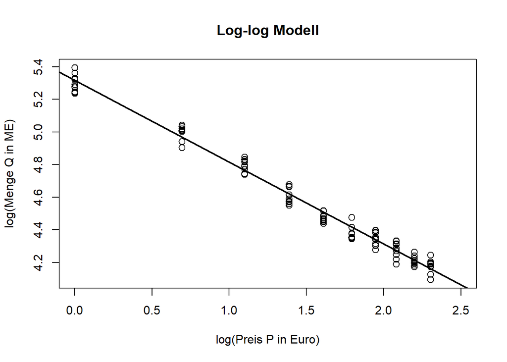

```r
plot(log(data$P), log(data$Q), cex = 1.2, xlab = "log(Preis P in Euro)",
     ylab = "log(Menge Q in ME)", main = "Log-log Modell",
     xlim = c(0, 2.5))
abline(lm(log(data$Q) ~ log(data$P)), lwd = 2)
```

In diesem Streudiagramm ist ein starker, negativer, linearer Zusammenhang zwischen den Logs zu erkennen.

Die Ausgabe der Modellparameter $\beta_0$ und $\beta_1$ erfolgt folgendermaßen:

```r
ols2 <- lm(log(data$Q) ~ log(data$P)); ols2
```

```
##
## Call:
## lm(formula = log(data$Q) ~ log(data$P))
##
## Coefficients:
## (Intercept)  log(data$P)
##       5.317       -0.502
```

Der Anstiegsparameter im log-log Modell kann als konstante **Elastizität** interpretiert werden. Hier ist die Prognose des Modells: Steigt der Preis um 1%, dann reduziert sich die Menge um 0.5%. Es liegt also eine unelastische Nachfrage vor.

Betrachten wir das Streudiagramm zwischen $u$ und $\widehat y$ (“Kontrollplot”).

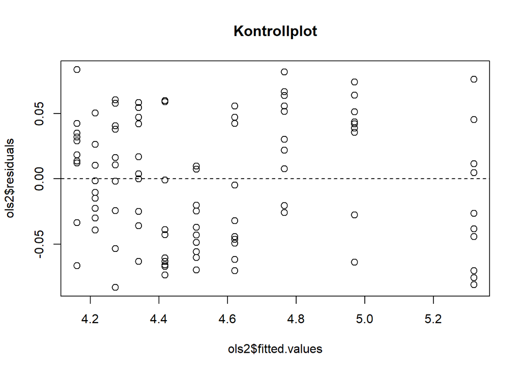

```r
plot(ols2$fitted.values, ols2$residuals, main = "Kontrollplot", cex = 1.2)
abline(h = 0, lty = 2)
```

Die Verteilung der Werte ist relativ unauffällig (zumindest aber besser als vor der Transformation).

```r
cor(log(data$Q), log(data$P), method = "pearson")^2
```

```
## [1] 0.98238
```

Das $R^2$ ist relativ hoch mit 98%. Der natürliche Log von $P$ kann 98% der Streuung des natürlichen Logs von $Q$ erklären.

Die Rücktransformation und grafische Darstellung im Plot für $P$ und $Q$ erfolgt folgendermaßen:

```r
log(2.718) # Der Log der Eulerschen Zahl e muss 1 sein
```

```
## [1] 0.9999
```

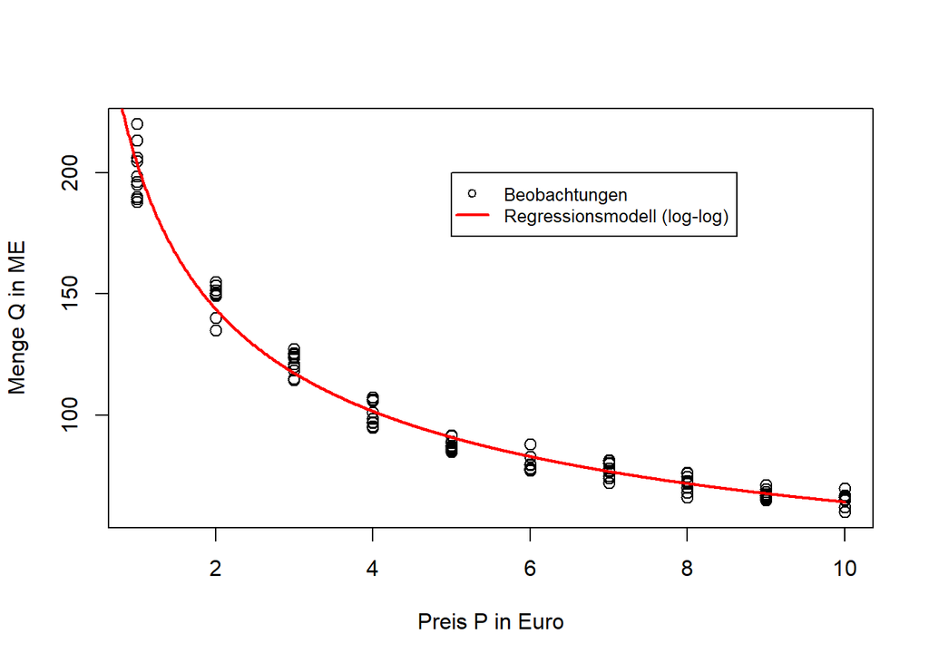

```r
P_ols <- seq(0, 10, 0.01)
Q_ols <- 2.718^(5.317 - 0.502*log(P_ols))
plot(data$P, data$Q, cex = 1.2, ylab = "Menge Q in ME", xlab = "Preis P in Euro")
lines(P_ols, Q_ols, lwd = 2, col = "red")
legend(5, 200, pch = c(1,NA), c("Beobachtungen","Regressionsmodell (log-log)"), lwd = c(NA,2),
col = c("black","red"), cex = 0.8)
```